# Identity Encoding Code 08:

Comparative Analysis between Monk Parakeets and Yellow-naped Amazons

[Grace Smith-Vidaurre](http://smith-vidaurre.com/)<sup>1-4*</sup> <sup>1</sup>Department of Biology, New Mexico State University <sup>2</sup>Laboratory of Neurogenetics of Language, Rockefeller University <sup>3</sup>Field Research Center, Rockefeller University <sup>4</sup>Department of Biological Sciences, University of Cincinnati *gsvidaurre@gmail.com

12 June, 2023

This code accompanies the following paper in PLOS Computational Biology:

Smith-Vidaurre, G., Perez-Marrufo, V., Hobson, E.A., Salinas-Melgoza, A., and T.F. Wright. 2023. Individual identity information persists in learned calls of introduced parrot populations.

We compared hierarchical mapping patterns between monk parakeets and yellow-naped amazons using a customized bootstrapping routine and SPCC similarity. In these analyses, I randomly sampled SPCC similarity values within and among categories at each social scale for native and introduced range monk parakeets (individual and site scales), as well as yellow-naped amazons (individual, site, and regional dialect scales). I used these randomly sampled distributions to make visualizations and calculate a bootstrapped similarity ratio to quantify the relative acoustic convergence at each social scale per species and range. See the methods and appendix of the associated publication for more information about these analyses.

Check out Github repositories from previous work for related analyses and code:

- gsvidaurre/strong-individual-signatures<sup>[1]</sup>
- gsvidaurre/simpler-signatures-post-invasion<sup>[2]</sup>

Please cite the associated papers and code (see DOIs on GitHub) if the code or analyses across these repositories are useful for your own research.

```r
rm(list = ls())

X <- c("tidyverse", "warbleR", "pbapply", "plyr", "dplyr", "data.table", "parallel", "scales", "ggplot2", "knitr", "gridExtra", "grid", "Rmisc", "ggpubr")

invisible(lapply(X, library, character.only = TRUE))

# Suppress summarise warnings from dplyr
options(dplyr.summarise.inform = FALSE)

path <- "/media/gsvidaurre/MYIOPSITTA/R/VocalLearning_PostDisruption/Data"
gpath <- "/home/gsvidaurre/Desktop/MANUSCRIPTS/Submitted_InReview/HierarchicalMapping_Introduction/FIGURES"
seed <- 401
cores <- parallel::detectCores() - 2

# Source customized functions:

# Read in a function to extract unique pairwise comparisons from a symmetric similarity matrix
source("/home/gsvidaurre/Desktop/GitHub_repos/identity-information-post-introduction/functions/extract_simValues.R")
```

Read in extended selection table (EST). Metadata and wave objects for pre-processed native and introduced range calls across the individual and site scales.

```r
nat_int_est <- readRDS(file.path(path, "monk_parakeet_contactCalls_rangeComparison_extSelTable.RDS"))
# glimpse(nat_int_est)
```

# Filtering out some calls

I dropped individual scale calls that had been added to the site scale (1 call per known repeatedly sampled individual in the final individual scale dataset, suffix “site_scale”).

```r
# 31 calls with the suffix "_site_scale". Not all of these belonged to the individuals in the final individual scale dataset, since some individuals that we repeatedly sampled were dropped due to low sample sizes after pre-processing
nat_int_est %>%
  dplyr::filter(social_scale == "Site") %>%
  dplyr::filter(grepl("_site_scale", sound.files)) %>%
  pull(sound.files) %>%
  length()
```

```
## [1] 31
```

```r
# Get the "_site_scale" calls for the final dataset of known repeatedly sampled individuals
indiv_ids <- nat_int_est %>%
  dplyr::filter(social_scale == "Individual") %>%
  pull(Bird_ID) %>%
  unique()

# 17 total: 8 native and 9 introduced range
indiv_ids
```

```
##  [1] "NAT-RAW"  "NAT-ZW8"  "NAT-UM2"  "NAT-UM3"  "NAT-UM4"  "NAT-UM1"
##  [7] "NAT-AAT"  "NAT-UM5"  "INT-UM1"  "INT-UM5"  "INT-UM6"  "INT-UM7"
## [13] "INT-UM9"  "INT-UM10" "INT-UM16" "INT-UM17" "INT-UM19"
```

```r
# INT-UM1, INT-UM6, and INT-UM19 were each the sole bird sampled at sites BART, ASCA, and CAME, respectively. These sites were not included at the site scale, so these individuals did not have any "_site_scale" calls
# This leaves 14 calls to drop, each representing a call for a different repeatedly sampled individual included in the site scale dataset
drop_is_calls <- nat_int_est %>%
  dplyr::filter(social_scale == "Site") %>%
  dplyr::filter(grepl("_site_scale", sound.files)) %>%
  dplyr::filter(Bird_ID %in% indiv_ids) %>%
  pull(sound.files)

length(drop_is_calls)
```

```
## [1] 14
```

```r
# Checking, looks good
# nat_int_est %>%
#   as_tibble() %>%
#   dplyr::filter(sound.files %in% drop_is_calls) %>%
#   dplyr::select(sound.files, Bird_ID) %>%
#   kable(align = rep("c", nrow(.)))

# Drop these calls from the extended selection table and continue with analyses
# nat_int_est <- nat_int_est %>%
  # dplyr::filter(!sound.files %in% drop_is_calls)

# Don't use tidyverse since I want to filter both the data frame and the .wav objects in the EST
nat_int_est <- nat_int_est[-grep(paste(paste("^", drop_is_calls, "$", sep = ""), collapse = "|"), nat_int_est$sound.files), ]

# 1582 calls remain out of the original 1596 calls read in above
dim(nat_int_est)
```

```
## [1] 1582   26
```

```r
class(nat_int_est)
```

```
## [1] "extended_selection_table" "data.frame"
```

```r
glimpse(nat_int_est)
```

```
## Rows: 1,582
## Columns: 26
## $ sound.files          <chr> "2017_07_17_EMBR_INDIV-RAW_MZ000199_1.WAV", "2017…
## $ selec                <dbl> 1, 1, 1, 1, 1, 1, 1, 1, 1, 1, 1, 1, 1, 1, 1, 1, 1…
## $ start                <dbl> 0.05, 0.05, 0.05, 0.05, 0.05, 0.05, 0.05, 0.05, 0…
## $ end                  <dbl> 0.2646363, 0.2310324, 0.2509257, 0.2378781, 0.220…
## $ date                 <date> 2017-07-17, 2017-07-17, 2017-07-17, 2017-07-17, …
## $ range                <chr> "Native", "Native", "Native", "Native", "Native",…
## $ social_scale         <chr> "Individual", "Individual", "Individual", "Indivi…
## $ site                 <chr> "EMBR", "EMBR", "EMBR", "EMBR", "EMBR", "EMBR", "…
## $ Bird_ID              <chr> "NAT-RAW", "NAT-RAW", "NAT-RAW", "NAT-RAW", "NAT-…
## $ lat                  <dbl> -34.44437, -34.44437, -34.44437, -34.44437, -34.4…
## $ lon                  <dbl> -57.72845, -57.72845, -57.72845, -57.72845, -57.7…
## $ Visual_quality_score <fct> H, M, H, H, M, M, M, H, M, H, H, H, M, M, H, H, H…
## $ Overlapping_signal   <fct> N, N, N, N, N, N, N, N, N, N, N, N, N, N, N, N, N…
## $ Truncated            <chr> "N", "N", "N", "N", "N", "N", "N", "N", "N", "N",…
## $ tailored             <fct> y, y, y, y, y, y, y, y, y, y, y, y, y, y, y, y, y…
## $ prev_SNR             <dbl> 20.10350, 14.90409, 18.55063, 18.49727, 18.74672,…
## $ SNR_margin_works     <chr> "Y", "Y", "Y", "Y", "Y", "Y", "Y", "Y", "Y", "Y",…
## $ SNR_before_only      <chr> NA, NA, NA, NA, NA, NA, NA, NA, NA, NA, NA, NA, N…
## $ old.sound.file.name  <chr> "2017_07_17_EMBR_INDIV-RAW_MZ000199_1.WAV", "2017…
## $ SNR                  <dbl> 23.45415, 22.14815, 15.36660, 19.25200, 21.86770,…
## $ region               <chr> "West", "West", "West", "West", "West", "West", "…
## $ country              <chr> "Uruguay", "Uruguay", "Uruguay", "Uruguay", "Urug…
## $ site_year            <chr> "EMBR_2017", "EMBR_2017", "EMBR_2017", "EMBR_2017…
## $ year                 <chr> "2017", "2017", "2017", "2017", "2017", "2017", "…
## $ dept_state           <chr> "Colonia", "Colonia", "Colonia", "Colonia", "Colo…
## $ introduced_city      <chr> NA, NA, NA, NA, NA, NA, NA, NA, NA, NA, NA, NA, N…
```

# SPCC for yellow-naped amazon calls

Make a selection table that has the starts and ends as the start and end of each cut.

```r
yna_path <- "/media/gsvidaurre/MYIOPSITTA/R/Uruguay2017_MonkParakeet_CallAnalysis/Data/YNA_published_data"

# Get the original .wav files
wavs <- list.files(path = yna_path, pattern = "YNA_R_1994_([A-z]+)([a-z]+)_([a-z]+)_([0-9]+).([0-9]+).wav$")
head(wavs)
length(wavs)

# Read in these original .wav files to make a new selection table
# w <- 1 # testing
yna_sels_df <- rbindlist(pblapply(1:length(wavs), function(w){

  tmp <- readWave(file.path(yna_path, wavs[w]))

  return(
    data.frame(
      sound.files = wavs[w],
      selec = 1,
      start = 0,
      end = duration(tmp),
      regional_dialect = strsplit(wavs[w], split = "_")[[1]][4],
      site = strsplit(wavs[w], split = "_")[[1]][5],
      bird_ID = paste(strsplit(wavs[w], split = "_")[[1]][5], gsub(".([0-9]+).wav", "", strsplit(wavs[w], split = "_")[[1]][6]), sep = "-"),
      sampling_rate = tmp@samp.rate
    )
  )

}))

glimpse(yna_sels_df)

# all .wav files are at a 22.050 kHz sampling rate
unique(yna_sels_df$sampling_rate)

write.csv(yna_sels_df, file.path(path, "Amazon_selection_table_1994calls.csv"), row.names = FALSE)

# Perform SPCC as in previous analyses
xc_mat_yna <- warbleR::cross_correlation(yna_sels_df, wl = 378, ovlp = 90, bp = c(0.5, 9), wn = "hanning", cor.method = "pearson", parallel = cores, na.rm = FALSE, type = "spectrogram", path = yna_path)

glimpse(xc_mat_yna)

# Change dimension names
wavs <- gsub(".wav-1", ".wav", dimnames(xc_mat_yna)[[1]])
head(wavs)

dimnames(xc_mat_yna) <- list(wavs, wavs)
str(xc_mat_yna)

saveRDS(xc_mat_yna, file.path(path, "xc_mat_yna_1994calls.RDS"))
```

## Validating yellow-naped amazon SPCC similarity values

```r
yna_sels_df <- read.csv(file.path(path, "Amazon_selection_table_1994calls.csv"))
glimpse(yna_sels_df)
```

```
## Rows: 441
## Columns: 8
## $ sound.files      <chr> "YNA_R_1994_Nic_penas_1.0.wav", "YNA_R_1994_Nic_penas…
## $ selec            <int> 1, 1, 1, 1, 1, 1, 1, 1, 1, 1, 1, 1, 1, 1, 1, 1, 1, 1,…
## $ start            <int> 0, 0, 0, 0, 0, 0, 0, 0, 0, 0, 0, 0, 0, 0, 0, 0, 0, 0,…
## $ end              <dbl> 0.2004082, 0.2220408, 0.2223583, 0.2907937, 0.2203628…
## $ regional_dialect <chr> "Nic", "Nic", "Nic", "Nic", "Nic", "Nic", "Nic", "Nic…
## $ site             <chr> "penas", "penas", "penas", "penas", "penas", "penas",…
## $ bird_ID          <chr> "penas-1", "penas-1", "penas-1", "penas-1", "penas-1"…
## $ sampling_rate    <int> 22050, 22050, 22050, 22050, 22050, 22050, 22050, 2205…
```

```r
xc_mat_yna <- readRDS(file.path(path, "xc_mat_yna_1994calls.RDS"))
glimpse(xc_mat_yna)
```

```
##  num [1:441, 1:441] 1 0.633 0.641 0.644 0.689 ...
##  - attr(*, "dimnames")=List of 2
##   ..$ : chr [1:441] "YNA_R_1994_Nic_penas_1.0.wav" "YNA_R_1994_Nic_penas_1.1.wav" "YNA_R_1994_Nic_penas_1.2.wav" "YNA_R_1994_Nic_penas_1.3.wav" ...
##   ..$ : chr [1:441] "YNA_R_1994_Nic_penas_1.0.wav" "YNA_R_1994_Nic_penas_1.1.wav" "YNA_R_1994_Nic_penas_1.2.wav" "YNA_R_1994_Nic_penas_1.3.wav" ...
```

Make an acoustic space plot to be sure the SPCC values recapitulate the patterns we expected for the amazons<sup>[3]</sup>.

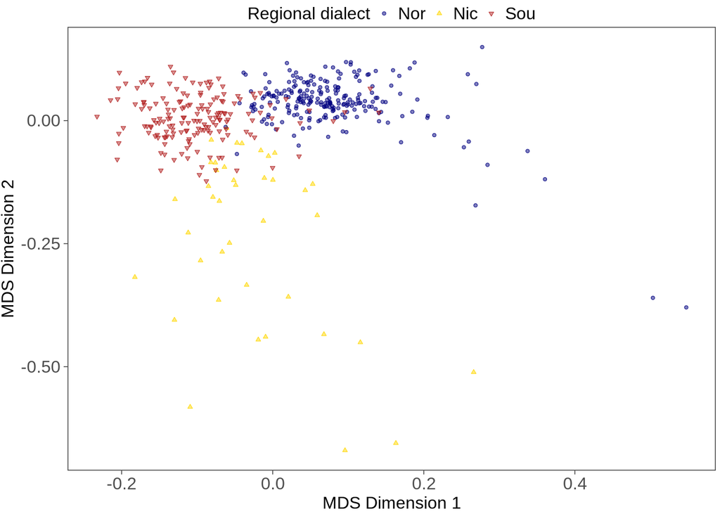

```r
# Convert to a distance matrix and dist object for isoMDS
dist_mat <- stats::as.dist(1 - xc_mat_yna, diag = TRUE, upper = TRUE)
# str(dist_mat)

# Reduce dimensionality of the SPCC matrix to visualize calls in 2D acoustic space
iso <- invisible(MASS::isoMDS(dist_mat, k = 15, maxit = 1000, trace = FALSE))
# str(iso) # stress is shown as a percentage

# Make a data frame of the first two MDS dimensions and call metadata
mds_df <- data.frame(sound.files = dimnames(iso$points)[[1]]) %>%
  dplyr::mutate(
    X = iso$points[, 1],
    Y = iso$points[, 2]
  ) %>%
  inner_join(
   yna_sels_df %>%
     as_tibble() %>%
     dplyr::select(sound.files, regional_dialect, site, bird_ID),
   by = c("sound.files")
  ) %>%
  dplyr::mutate(
    regional_dialect = factor(regional_dialect, levels = c("Nor", "Nic", "Sou"))
  )

# glimpse(mds_df)

# Colors by dialect
cols <- scales::alpha(c("navy", "gold", "firebrick"), 1)

fills <- scales::alpha(c("navy", "gold", "firebrick"), 0.5)

# Shapes by dialect
shps <- c(21, 24, 25)

mds_df %>%
  ggplot(aes(x = X, y = Y, shape = regional_dialect)) +
  geom_point(aes(fill = regional_dialect, color = regional_dialect), size = 1, stroke = 0.25) +
  scale_shape_manual(values = shps) +
  scale_color_manual(values = cols) +
  scale_fill_manual(values = fills) +
  xlab("MDS Dimension 1") + ylab("MDS Dimension 2") +
  guides(color = guide_legend(title = "Regional dialect", nrow = 1, byrow = TRUE), shape = guide_legend(title = "Regional dialect", nrow = 1, byrow = TRUE), fill = guide_legend(title = "Regional dialect", nrow = 1, byrow = TRUE)) +
  theme_bw() +
  theme(
    axis.title = element_text(size = 12),
    axis.text = element_text(size = 12),
    legend.title = element_text(size = 12),
    legend.text = element_text(size = 12),
    legend.justification = "center",
    panel.grid.major = element_blank(),
    panel.grid.minor = element_blank(),
    axis.ticks = element_line(linewidth = 0.25),
    legend.position = "top",
    legend.margin = margin(0, 0, 0, 0),
    legend.box.margin = margin(3, -5, -7, -5), # top, right, bottom, left
    legend.key.width = unit(0.5, "lines"),
    legend.key.height = unit(0.5, "lines"),
    plot.margin = margin(1, 3, 1, 1)
  )
```

```r
# ggsave(file.path(gpath, "amazon_validation_acousticSpace.tiff"), units = "in", width = 3.5, height = 3, dpi = 300)
```

Get all pairwise comparisons in the yellow-naped amazon SPCC matrix and visualize the full distribution of these values.

```r
# Melt the pairwise symmetric matrix into a longer data frame such that each row is a pairwise comparison (upper and lower triangle comparisons are all here so comparisons are duplicated, diagonal is included)
paircomp_yna_df <- reshape2::melt(xc_mat_yna, varnames = c("target_call", "other_call"), na.rm = TRUE)
glimpse(paircomp_yna_df)
```

```
## Rows: 194,481
## Columns: 3
## $ target_call <fct> YNA_R_1994_Nic_penas_1.0.wav, YNA_R_1994_Nic_penas_1.1.wav…
## $ other_call  <fct> YNA_R_1994_Nic_penas_1.0.wav, YNA_R_1994_Nic_penas_1.0.wav…
## $ value       <dbl> 1.0000000, 0.6331682, 0.6407639, 0.6439480, 0.6888417, 0.6…
```

```r
# Mean of 0.72 for all SPCC values in the full matrix
round(mean(paircomp_yna_df$value), 2)
```

```
## [1] 0.72
```

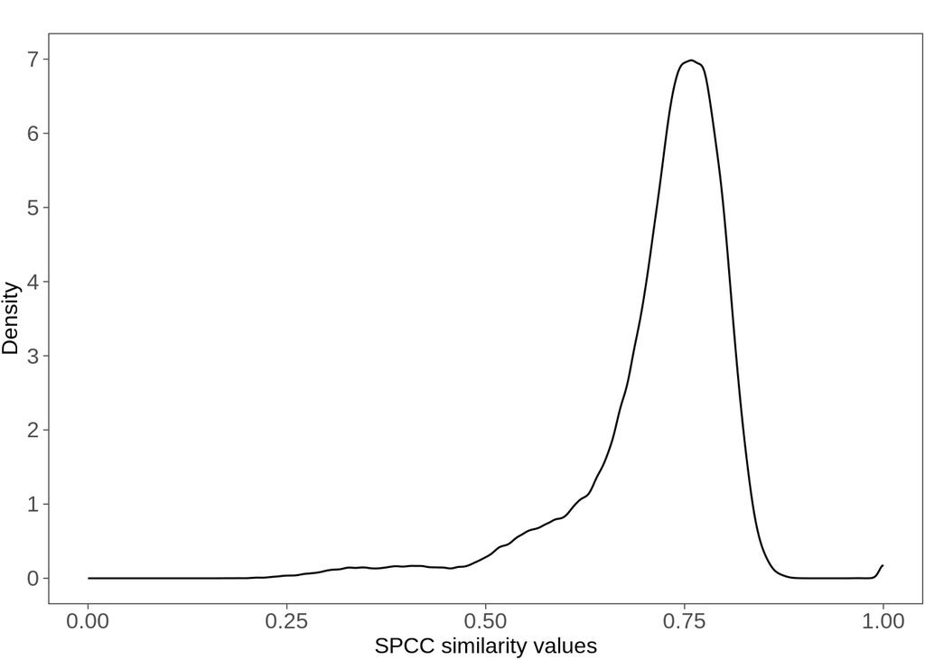

```r
paircomp_yna_df %>%
  ggplot() +
  geom_density(aes(x = value), linewidth = 0.5) +
  ggtitle("") +
  guides(fill = "none", color = "none") +
  xlab("SPCC similarity values") +
  ylab("Density") +
  scale_x_continuous(limits = c(0, 1)) +
  scale_y_continuous(limits = c(0, 7), breaks = seq(0, 7, 1), labels = seq(0, 7, 1)) +
  theme_bw() +
  theme(
    plot.margin = ggplot2::margin(1, 1, 1, 1), # top, right, bottom, left
    panel.grid.major = element_blank(),
    panel.grid.minor = element_blank(),
    axis.text.x = element_text(size = 12),
    axis.text.y = element_text(size = 12),
    axis.title = element_text(size = 12),
    axis.ticks = element_line(linewidth = 0.25)
  )
```

```r
# ggsave(file.path(gpath, "amazon_allspcc_values_density.tiff"), units = "in", width = 3.5, height = 3, dpi = 300)
```

# SPCC for downsampled monk parakeet calls

I downsampled the 1582 monk parakeet contact calls to 22.05 kHz to match the yellow-naped amazon sampling rates.

```r
nat_int_est_ds <- resample_est_waves(nat_int_est, samp.rate = 22.05, bit.depth = 16, avoid.clip = TRUE, pb = TRUE)
glimpse(nat_int_est_ds)

class(nat_int_est_ds)
length(attr(nat_int_est_ds, "wave.objects"))

saveRDS(nat_int_est_ds, file.path(path, "nat_int_est_ds.RDS"))
```

Then I reran SPCC with the downsampled monk parakeet calls.

```r
nat_int_est_ds <- readRDS(file.path(path, "nat_int_est_ds.RDS"))
glimpse(nat_int_est_ds)

# Perform SPCC as in previous analyses
xc_mat_mnk_ds <- warbleR::cross_correlation(nat_int_est_ds, wl = 378, ovlp = 90, wn = "hanning", cor.method = "pearson", parallel = cores, na.rm = FALSE, bp = c(0.5, 9), output = "cor.mat", path = path, type = "fourier")

glimpse(xc_mat_mnk_ds)

# Change dimension names
wavs <- gsub(".WAV-1", ".WAV", dimnames(xc_mat_mnk_ds)[[1]])
head(wavs)

dimnames(xc_mat_mnk_ds) <- list(wavs, wavs)
str(xc_mat_mnk_ds)

saveRDS(xc_mat_mnk_ds, file.path(path, "xc_mat_mnk_ds.RDS"))
```

## Validating monk parakeet SPCC similarity values

```r
xc_mat_mnk_ds <- readRDS(file.path(path, "xc_mat_mnk_ds.RDS"))
str(xc_mat_mnk_ds)
```

```
##  num [1:1582, 1:1582] 1 0.304 0.436 0.447 0.414 ...
##  - attr(*, "dimnames")=List of 2
##   ..$ : chr [1:1582] "2017_07_17_EMBR_INDIV-RAW_MZ000199_1.WAV" "2017_07_17_EMBR_INDIV-RAW_MZ000199_2.WAV" "2017_07_17_EMBR_INDIV-RAW_MZ000202_1.WAV" "2017_07_17_EMBR_INDIV-RAW_MZ000202_2.WAV" ...
##   ..$ : chr [1:1582] "2017_07_17_EMBR_INDIV-RAW_MZ000199_1.WAV" "2017_07_17_EMBR_INDIV-RAW_MZ000199_2.WAV" "2017_07_17_EMBR_INDIV-RAW_MZ000202_1.WAV" "2017_07_17_EMBR_INDIV-RAW_MZ000202_2.WAV" ...
```

Check out the full distribution of SPCC values for all monk parakeet calls recorded in each of the native and introduced ranges. This distribution includes the diagonal and upper and lower triangles.

```r
# Melt the pairwise symmetric matrix into a longer data frame such that each row is a pairwise comparison (upper and lower triangle comparisons are all here so comparisons are duplicated, diagonal is included)
tmp_df <- reshape2::melt(xc_mat_mnk_ds, varnames = c("target_call", "other_call"), na.rm = TRUE)

paircomp_mnk_df <- tmp_df %>%
  # Add metadata for the target calls
  inner_join(
    nat_int_est %>%
      dplyr::filter(sound.files %in% tmp_df$target_call) %>%
      as_tibble() %>%
      dplyr::select(sound.files, Bird_ID, site_year, range, social_scale),
    by = c("target_call" = "sound.files")
  ) %>%
  dplyr::rename(
        `target_bird_ID` = "Bird_ID",
        `target_site` = "site_year",
        `target_range` = "range",
        `target_comp_ss` = "social_scale"
      ) %>%
      # Add metadata for the other calls used for comparison
      inner_join(
        nat_int_est %>%
          dplyr::filter(sound.files %in% tmp_df$other_call) %>%
          as_tibble() %>%
          dplyr::select(sound.files, Bird_ID, site_year, range),
        by = c("other_call" = "sound.files")
      ) %>%
      dplyr::rename(
        `other_bird_ID` = "Bird_ID",
        `other_site` = "site_year",
        `other_range` = "range"
      )

glimpse(paircomp_mnk_df)
```

```
## Rows: 2,502,724
## Columns: 10
## $ target_call    <chr> "2017_07_17_EMBR_INDIV-RAW_MZ000199_1.WAV", "2017_07_17…
## $ other_call     <chr> "2017_07_17_EMBR_INDIV-RAW_MZ000199_1.WAV", "2017_07_17…
## $ value          <dbl> 1.0000000, 0.3037182, 0.4359429, 0.4465968, 0.4143729, …
## $ target_bird_ID <chr> "NAT-RAW", "NAT-RAW", "NAT-RAW", "NAT-RAW", "NAT-ZW8", …
## $ target_site    <chr> "EMBR_2017", "EMBR_2017", "EMBR_2017", "EMBR_2017", "EM…
## $ target_range   <chr> "Native", "Native", "Native", "Native", "Native", "Nati…
## $ target_comp_ss <chr> "Individual", "Individual", "Individual", "Individual",…
## $ other_bird_ID  <chr> "NAT-RAW", "NAT-RAW", "NAT-RAW", "NAT-RAW", "NAT-RAW", …
## $ other_site     <chr> "EMBR_2017", "EMBR_2017", "EMBR_2017", "EMBR_2017", "EM…
## $ other_range    <chr> "Native", "Native", "Native", "Native", "Native", "Nati…
```

```r
# Mean of 0.32 for all SPCC values in the full matrix
round(mean(paircomp_mnk_df$value), 2)
```

```
## [1] 0.32
```

```r
# Mean of 0.39 for the full set of native range values
paircomp_mnk_df %>%
  dplyr::filter(target_range == "Native" & other_range == "Native") %>%
  pull(value) %>%
  mean() %>%
  round(., 2)
```

```
## [1] 0.39
```

```r
# Mean of 0.3 for the full set of introduced range values
paircomp_mnk_df %>%
  dplyr::filter(target_range == "Introduced" & other_range == "Introduced") %>%
  pull(value) %>%
  mean() %>%
  round(., 2)
```

```
## [1] 0.3
```

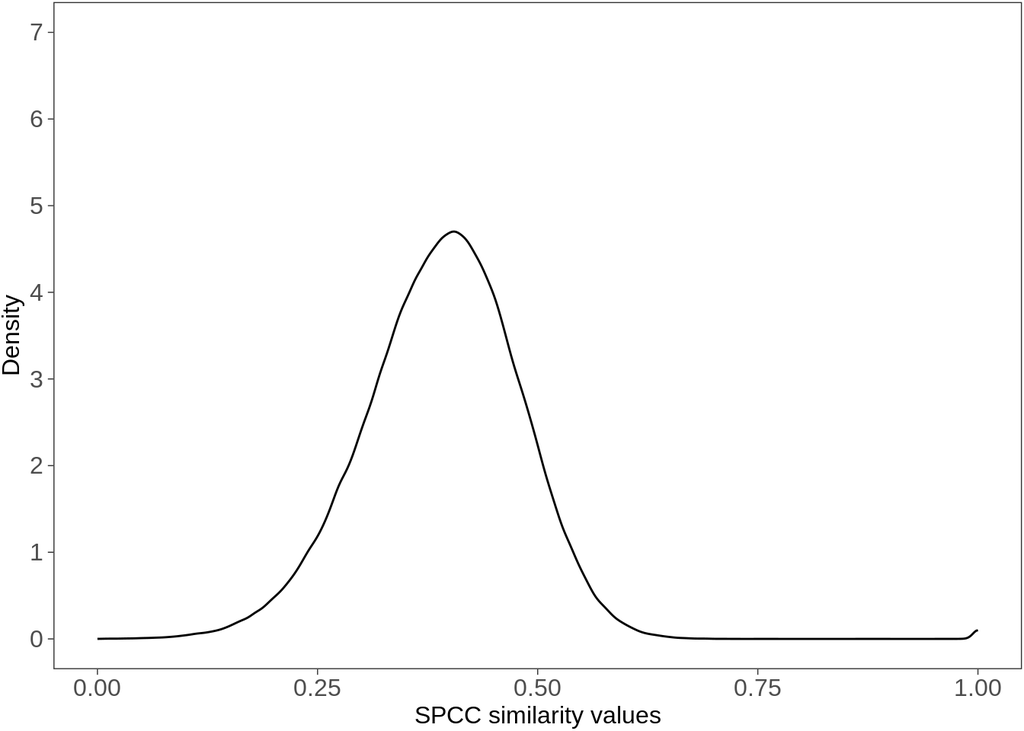

```r
paircomp_mnk_df %>%
  dplyr::filter(target_range == "Native" & other_range == "Native") %>%
  ggplot() +
  geom_density(aes(x = value), linewidth = 0.5) +
  guides(fill = "none", color = "none") +
  xlab("SPCC similarity values") +
  ylab("Density") +
  scale_x_continuous(limits = c(0, 1)) +
  scale_y_continuous(limits = c(0, 7), breaks = seq(0, 7, 1), labels = seq(0, 7, 1)) +
  theme_bw() +
  theme(
    plot.margin = ggplot2::margin(1, 1, 1, 1), # top, right, bottom, left
    panel.grid.major = element_blank(),
    panel.grid.minor = element_blank(),
    axis.text.x = element_text(size = 12),
    axis.text.y = element_text(size = 12),
    axis.title = element_text(size = 12),
    axis.ticks = element_line(linewidth = 0.25)
  )
```

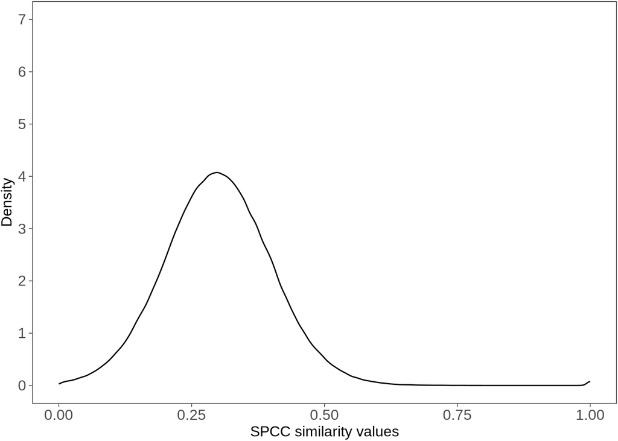

```r
# ggsave(file.path(gpath, "nativeParakeet_allspcc_values_density.tiff"), units = "in", width = 3.5, height = 3, dpi = 300)


paircomp_mnk_df %>%
  dplyr::filter(target_range == "Introduced" & other_range == "Introduced") %>%
  ggplot() +
  geom_density(aes(x = value), linewidth = 0.5) +
  guides(fill = "none", color = "none") +
  xlab("SPCC similarity values") +
  ylab("Density") +
  scale_x_continuous(limits = c(0, 1)) +
  scale_y_continuous(limits = c(0, 7), breaks = seq(0, 7, 1), labels = seq(0, 7, 1)) +
  theme_bw() +
  theme(
    plot.margin = ggplot2::margin(1, 1, 1, 1), # top, right, bottom, left
    panel.grid.major = element_blank(),
    panel.grid.minor = element_blank(),
    axis.text.x = element_text(size = 12),
    axis.text.y = element_text(size = 12),
    axis.title = element_text(size = 12),
    axis.ticks = element_line(linewidth = 0.25)
  )
```

```r
# ggsave(file.path(gpath, "introducedParakeet_allspcc_values_density.tiff"), units = "in", width = 3.5, height = 3, dpi = 300)
```

# Get yellow-naped amazon SPCC values across social scales

For yellow-naped amazon analyses, I focused on calls classified into either the North and South dialects that were generally visibly and audibly distinctive to the human eye and ear<sup>[3]</sup><sup>[4]</sup>. For the individual and site scale analyses, I focused on call comparisons within the North dialect, and for the regional dialect analyses I focused on comparing calls from the North and South dialects.

Here I obtained pairwise comparisons at the individual, site, and regional dialect social scales for yellow-naped amazon calls. I used the customized function I designed to extract similarity values representing all pairwise comparisons among calls of interest (no values along the diagonal, and duplicated comparisons from the symmetrix matrix are retained but will be dropped later).

Individual scale comparison: same or different individual, same site, same dialect (North)

```r
# How many birds per Northern dialect site?
# 2 - 4 birds
yna_sels_df %>%
  dplyr::filter(regional_dialect == "Nor") %>%
  group_by(site) %>%
  dplyr::summarise(
    n_birds = n_distinct(bird_ID)
  )
```

```
## # A tibble: 7 × 2
##   site  n_birds
##   <chr>   <int>
## 1 belen       3
## 2 cabu        2
## 3 horiz       4
## 4 inoc        4
## 5 junq        4
## 6 pelal       4
## 7 pnar        4
```

```r
# Randomly select 3 North dialect sites for the individual scale, to match the maximum number of sites at which we repeatedly sampled monk parakeet individuals
set.seed(seed)

sites4indivs <- yna_sels_df %>%
  dplyr::filter(regional_dialect == "Nor") %>%
  pull(site) %>%
  unique() %>%
  sample(., 3, replace = FALSE)
```

```r
# inoc, junq, pelal: all have 4 individuals, so the individual scale comparison will be performed with calls of 12 repeatedly sampled birds
sites4indivs
```

```
## [1] "inoc"  "junq"  "pelal"
```

```r
# Individual scale comparison: same or different individual, same site/dialect
indiv_calls <- yna_sels_df %>%
  dplyr::filter(site %in% sites4indivs) %>%
  pull(sound.files)

head(indiv_calls)
```

```
## [1] "YNA_R_1994_Nor_inoc_1.0.wav" "YNA_R_1994_Nor_inoc_1.1.wav"
## [3] "YNA_R_1994_Nor_inoc_1.2.wav" "YNA_R_1994_Nor_inoc_1.3.wav"
## [5] "YNA_R_1994_Nor_inoc_1.4.wav" "YNA_R_1994_Nor_inoc_1.5.wav"
```

```r
length(indiv_calls)
```

```
## [1] 117
```

```r
# Extract the similarity values for the pairwise comparisons of interest at this social scale
indiv_comparisons_df <- extract_simValues(sim_mat = xc_mat_yna, calls = indiv_calls, species = "yellow-naped amazon", social_scale = "Individual", dataset = NA, similarity_method = "SPCC", city_year = NA, metadata_df = yna_sels_df, analysis_type = "bootstrap")

glimpse(indiv_comparisons_df)
```

```
## Rows: 4,452
## Columns: 16
## $ indiv_comparison_type   <chr> "same", "same", "same", "same", "same", "same"…
## $ site_comparison_type    <chr> "same", "same", "same", "same", "same", "same"…
## $ dialect_comparison_type <chr> "same", "same", "same", "same", "same", "same"…
## $ similarity_value        <dbl> 0.8424411, 0.8582592, 0.8600315, 0.8439564, 0.…
## $ target_call             <chr> "YNA_R_1994_Nor_inoc_1.1.wav", "YNA_R_1994_Nor…
## $ other_call              <chr> "YNA_R_1994_Nor_inoc_1.0.wav", "YNA_R_1994_Nor…
## $ target_bird_ID          <chr> "inoc-1", "inoc-1", "inoc-1", "inoc-1", "inoc-…
## $ other_bird_ID           <chr> "inoc-1", "inoc-1", "inoc-1", "inoc-1", "inoc-…
## $ target_site             <chr> "inoc", "inoc", "inoc", "inoc", "inoc", "inoc"…
## $ other_site              <chr> "inoc", "inoc", "inoc", "inoc", "inoc", "inoc"…
## $ target_dialect          <chr> "Nor", "Nor", "Nor", "Nor", "Nor", "Nor", "Nor…
## $ other_dialect           <chr> "Nor", "Nor", "Nor", "Nor", "Nor", "Nor", "Nor…
## $ type                    <chr> "within", "within", "within", "within", "withi…
## $ dataset                 <lgl> NA, NA, NA, NA, NA, NA, NA, NA, NA, NA, NA, NA…
## $ similarity_method       <chr> "SPCC", "SPCC", "SPCC", "SPCC", "SPCC", "SPCC"…
## $ city_year               <lgl> NA, NA, NA, NA, NA, NA, NA, NA, NA, NA, NA, NA…
```

```r
# Checking: the two comparison types are same individual/site/dialect versus different individual same site/dialect, looks good
indiv_comparisons_df %>%
  distinct(indiv_comparison_type, site_comparison_type, dialect_comparison_type)
```

```
##   indiv_comparison_type site_comparison_type dialect_comparison_type
## 1                  same                 same                    same
## 2             different                 same                    same
```

```r
indiv_comparisons_df %>%
  pull(target_bird_ID) %>%
  table()
```

```
## .
##  inoc-1  inoc-2  inoc-3  inoc-4  junq-1  junq-2  junq-3  junq-4 pelal-1 pelal-2
##     360     360     324     288     390     390     390     390     390     390
## pelal-3 pelal-4
##     390     390
```

```r
indiv_comparisons_df %>%
  pull(target_site) %>%
  table()
```

```
## .
##  inoc  junq pelal
##  1332  1560  1560
```

```r
indiv_comparisons_df %>%
  pull(target_dialect) %>%
  table()
```

```
## .
##  Nor
## 4452
```

Site scale comparison: different individuals, same or different site, same dialect (North)

```r
# Get all calls for sites in the North dialect
site_calls <- yna_sels_df %>%
  dplyr::filter(regional_dialect == "Nor") %>%
  pull(sound.files)

head(site_calls)
```

```
## [1] "YNA_R_1994_Nor_belen_1.0.wav" "YNA_R_1994_Nor_belen_1.1.wav"
## [3] "YNA_R_1994_Nor_belen_1.2.wav" "YNA_R_1994_Nor_belen_1.3.wav"
## [5] "YNA_R_1994_Nor_belen_1.4.wav" "YNA_R_1994_Nor_belen_1.5.wav"
```

```r
length(site_calls)
```

```
## [1] 232
```

```r
# Extract the similarity values for the pairwise comparisons of interest at this social scale
site_comparisons_df <- extract_simValues(sim_mat = xc_mat_yna, calls = site_calls, species = "yellow-naped amazon", social_scale = "Site", dataset = NA, similarity_method = "SPCC", city_year = NA, metadata_df = yna_sels_df, analysis_type = "bootstrap")

glimpse(site_comparisons_df)
```

```
## Rows: 51,606
## Columns: 16
## $ indiv_comparison_type   <chr> "different", "different", "different", "differ…
## $ site_comparison_type    <chr> "same", "same", "same", "same", "same", "same"…
## $ dialect_comparison_type <chr> "same", "same", "same", "same", "same", "same"…
## $ similarity_value        <dbl> 0.7993412, 0.8322664, 0.7985120, 0.8265636, 0.…
## $ target_call             <chr> "YNA_R_1994_Nor_belen_2.0.wav", "YNA_R_1994_No…
## $ other_call              <chr> "YNA_R_1994_Nor_belen_1.0.wav", "YNA_R_1994_No…
## $ target_bird_ID          <chr> "belen-2", "belen-2", "belen-2", "belen-2", "b…
## $ other_bird_ID           <chr> "belen-1", "belen-1", "belen-1", "belen-1", "b…
## $ target_site             <chr> "belen", "belen", "belen", "belen", "belen", "…
## $ other_site              <chr> "belen", "belen", "belen", "belen", "belen", "…
## $ target_dialect          <chr> "Nor", "Nor", "Nor", "Nor", "Nor", "Nor", "Nor…
## $ other_dialect           <chr> "Nor", "Nor", "Nor", "Nor", "Nor", "Nor", "Nor…
## $ type                    <chr> "within", "within", "within", "within", "withi…
## $ dataset                 <lgl> NA, NA, NA, NA, NA, NA, NA, NA, NA, NA, NA, NA…
## $ similarity_method       <chr> "SPCC", "SPCC", "SPCC", "SPCC", "SPCC", "SPCC"…
## $ city_year               <lgl> NA, NA, NA, NA, NA, NA, NA, NA, NA, NA, NA, NA…
```

```r
# Checking: the two comparison types are different individual same site/dialect versus different individual and different site same dialect, looks good
site_comparisons_df %>%
  distinct(indiv_comparison_type, site_comparison_type, dialect_comparison_type)
```

```
##   indiv_comparison_type site_comparison_type dialect_comparison_type
## 1             different                 same                    same
## 2             different            different                    same
```

```r
site_comparisons_df %>%
  pull(target_site) %>%
  table()
```

```
## .
## belen  cabu horiz  inoc  junq pelal  pnar
##  6232  2907  8880  8239  8880  8880  7588
```

```r
site_comparisons_df %>%
  pull(target_dialect) %>%
  table()
```

```
## .
##   Nor
## 51606
```

Regional dialect scale comparison: different individuals, different sites, same or different dialects (North vs South)

```r
# Get all calls for sites in the North and South dialects
dialect_calls <- yna_sels_df %>%
  dplyr::filter(grepl("Nor|Sou", regional_dialect)) %>%
  pull(sound.files)

head(dialect_calls)
```

```
## [1] "YNA_R_1994_Nor_belen_1.0.wav" "YNA_R_1994_Nor_belen_1.1.wav"
## [3] "YNA_R_1994_Nor_belen_1.2.wav" "YNA_R_1994_Nor_belen_1.3.wav"
## [5] "YNA_R_1994_Nor_belen_1.4.wav" "YNA_R_1994_Nor_belen_1.5.wav"
```

```r
length(dialect_calls)
```

```
## [1] 401
```

```r
# Extract the similarity values for the pairwise comparisons of interest at this social scale
dialect_comparisons_df <- extract_simValues(sim_mat = xc_mat_yna, calls = dialect_calls, species = "yellow-naped amazon", social_scale = "Regional Dialect", dataset = NA, similarity_method = "SPCC", city_year = NA, metadata_df = yna_sels_df, analysis_type = "bootstrap")

glimpse(dialect_comparisons_df)
```

```
## Rows: 147,312
## Columns: 16
## $ indiv_comparison_type   <chr> "different", "different", "different", "differ…
## $ site_comparison_type    <chr> "different", "different", "different", "differ…
## $ dialect_comparison_type <chr> "same", "same", "same", "same", "same", "same"…
## $ similarity_value        <dbl> 0.7864194, 0.7645717, 0.8031079, 0.7826856, 0.…
## $ target_call             <chr> "YNA_R_1994_Nor_cabu_1.0.wav", "YNA_R_1994_Nor…
## $ other_call              <chr> "YNA_R_1994_Nor_belen_1.0.wav", "YNA_R_1994_No…
## $ target_bird_ID          <chr> "cabu-1", "cabu-1", "cabu-1", "cabu-1", "cabu-…
## $ other_bird_ID           <chr> "belen-1", "belen-1", "belen-1", "belen-1", "b…
## $ target_site             <chr> "cabu", "cabu", "cabu", "cabu", "cabu", "cabu"…
## $ other_site              <chr> "belen", "belen", "belen", "belen", "belen", "…
## $ target_dialect          <chr> "Nor", "Nor", "Nor", "Nor", "Nor", "Nor", "Nor…
## $ other_dialect           <chr> "Nor", "Nor", "Nor", "Nor", "Nor", "Nor", "Nor…
## $ type                    <chr> "within", "within", "within", "within", "withi…
## $ dataset                 <lgl> NA, NA, NA, NA, NA, NA, NA, NA, NA, NA, NA, NA…
## $ similarity_method       <chr> "SPCC", "SPCC", "SPCC", "SPCC", "SPCC", "SPCC"…
## $ city_year               <lgl> NA, NA, NA, NA, NA, NA, NA, NA, NA, NA, NA, NA…
```

```r
# Checking: looks good
dialect_comparisons_df %>%
  distinct(indiv_comparison_type, site_comparison_type, dialect_comparison_type)
```

```
##   indiv_comparison_type site_comparison_type dialect_comparison_type
## 1             different            different                    same
## 2             different            different               different
```

```r
dialect_comparisons_df %>%
  pull(target_site) %>%
  table()
```

```
## .
##  baju belen  cabu  curu grand horiz  inoc  junq pelal  pnar psapa  tarc zapol
## 14440 10444  5044  7258  9400 14440 13468 14440 14440 12478  7620  9400 14440
```

```r
dialect_comparisons_df %>%
  pull(target_dialect) %>%
  table()
```

```
## .
##   Nor   Sou
## 84754 62558
```

Combine these pairwise comparisons into a single data frame for the bootstrapping analysis that follows. These similarity values represent all pairwise comparisons among calls (duplicate comparisons are present here, and will be removed below when filtering by target bird, site, or dialect IDs).

```r
# Combine these data frames per social scale into a list to extract values in the loop below
grps_dfs <- list(

  indiv_comparisons_df %>%
    dplyr::mutate(
      target_grp_ids = target_bird_ID
    ),

  site_comparisons_df  %>%
    dplyr::mutate(
      target_grp_ids = target_site
    ),

  dialect_comparisons_df  %>%
    dplyr::mutate(
      target_grp_ids = target_dialect
    )
)

# glimpse(grps_dfs)
```

Extract SPCC values across these social scales and save to a .csv file to facilitate making a visual for the main manuscript. These values will be used for a visual of SPCC distributions within versus among categories (individuals or groups) at each social scale.

```r
# Amazons: iterate over social scales
social_scales <- c("Individual Scale", "Site Scale", "Regional Dialect Scale")
social_scales

# i <- 3
# z <- 1 # testing
yna_spcc_vals_df <- rbindlist(pblapply(1:length(social_scales), function(i){

  # Get the groups that will be used to pull out similarity values for the given social scale
  tmp_df <- grps_dfs[[i]]

  ids <- tmp_df %>%
    pull(target_grp_ids) %>%
    unique()

  # Subset the data frame of pairwise comparisons for the given social scale
  if(social_scales[i] == "Individual Scale"){

    id_col_nm <- "target_bird_ID"
    comp_col_nm <- "indiv_comparison_type"
    oth_id_col_nm <- "other_bird_ID"

  } else if(social_scales[i] == "Site Scale"){

    id_col_nm <- "target_site"
    comp_col_nm <- "site_comparison_type"
    oth_id_col_nm <- "other_site"

  } else if(social_scales[i] == "Regional Dialect Scale"){

    id_col_nm <- "target_dialect"
    comp_col_nm <- "dialect_comparison_type"
    oth_id_col_nm <- "other_dialect"

  }

  # Iterate over the unique groups to pull out similarity values for unique comparisons within versus among groups
  res_df <- rbindlist(lapply(1:length(ids), function(z){

    id <- ids[z]

    # Checking: The given data frame of similarity values should have all of the  non-unique pairwise comparisons for the given target group. Looks good. Below the similarity values for the unique comparisons only will be retained by filtering on the target ID column
    # tmp_df %>%
    #   dplyr::filter(!!rlang::sym(id_col_nm) == id) %>%
    #   pull(!!rlang::sym(comp_col_nm)) %>%
    #   table()
    #
    # tmp_df %>%
    #   dplyr::filter(!!rlang::sym(oth_id_col_nm) == id) %>%
    #   pull(!!rlang::sym(comp_col_nm)) %>%
    #   table()

    # Get the values within the given group
    tmp_df_w <- tmp_df %>%
      dplyr::filter(!!rlang::sym(id_col_nm) == id) %>%
      dplyr::filter(!!rlang::sym(comp_col_nm) == "same") %>%
      as_tibble()

    # glimpse(tmp_df_w)

    # Get the values among this group and others
    # For the individual scale, this will be other individuals at the same site
    # For the site scale, this will be other sites within the same dialect
    tmp_df_a <- tmp_df %>%
      dplyr::filter(!!rlang::sym(id_col_nm) == id) %>%
      dplyr::filter(!!rlang::sym(comp_col_nm) == "different") %>%
      as_tibble()

    # glimpse(tmp_df_a)

    return(
      tmp_df_w %>%
        bind_rows(
          tmp_df_a
        ) %>%
        dplyr::mutate(
          spp = "Yellow-naped amazon",
          range = "Native",
          dataset = "",
          social_scale = social_scales[i],
          target_group = ids[z],
          type = !!rlang::sym(comp_col_nm)
        ) %>%
        dplyr::select(spp, range, dataset, social_scale, target_group, type, similarity_value) %>%
        as_tibble()
    )

  }))

  return(res_df)

}))

glimpse(yna_spcc_vals_df)

write.csv(yna_spcc_vals_df, file.path(path, "amazon_spcc_social_scales.csv"), row.names = FALSE)
```

# Bootstrap yellow-naped amazon similarity values over social scales

I performed a bootstrapping analysis to compare SPCC similarity within and among sites for monk parakeets to yellow-naped amazons, a species with well-documented convergence at the site scale, and regional dialects<sup>[1]</sup>. For the monk parakeet data, I used all 3 site scale datasets, and performed bootstrapping for a comparison between ranges.

Do the bootstrapping with the list of data frames generated above.

Individual Scale: Sample 5 same and 5 different comparisons among individuals from the same site

Site Scale: Sample 5 same and 5 different comparisons among sites from the same regional dialect

Regional Dialect Scale: Sample 5 same and 5 different comparisons between the Northern and Southern dialects

In each of 200 bootstrapping iterations, calculate 5 similarity ratios by dividing the values for the within category comparisons by the values for the among category comparisons.

```r
# Amazons: iterate over social scales
social_scales <- c("Individual Scale", "Site Scale", "Regional Dialect Scale")
social_scales

iter <- 200
n <- 5 # the number of similarity values (uniqyue pairwise comparisons) that will be sampled with replacement

# i <- 1
# x <- 1
# z <- 1 # testing
yna_bs_sim_ratio_df <- data.table::rbindlist(pblapply(1:length(social_scales), function(i){

  # Get the groups that will be used to pull out similarity values for the given social scale
  tmp_df <- grps_dfs[[i]]

  ids <- tmp_df %>%
    pull(target_grp_ids) %>%
    unique()

  # Subset the data frame of pairwise comparisons for the given social scale
  if(social_scales[i] == "Individual Scale"){

    id_col_nm <- "target_bird_ID"
    comp_col_nm <- "indiv_comparison_type"

  } else if(social_scales[i] == "Site Scale"){

    id_col_nm <- "target_site"
    comp_col_nm <- "site_comparison_type"

  } else if(social_scales[i] == "Regional Dialect Scale"){

    id_col_nm <- "target_dialect"
    comp_col_nm <- "dialect_comparison_type"

  }

  # Per individual or group at the given social scale, randomly choose 5 values within and 5 values among categories with replacement for 200 iterations. So each individual or group should have 1000 representative similarity ratios
  bs_df <- rbindlist(lapply(1:length(ids), function(x){

    id <- ids[x]

    bs_df2 <- rbindlist(lapply(1:iter, function(z){

      # Get unique pairwise comparisons within the given group
      w_df <- tmp_df %>%
        dplyr::filter(!!rlang::sym(id_col_nm) == id) %>%
        dplyr::filter(!!rlang::sym(comp_col_nm) == "same") %>%
        as_tibble()

      # Get unique pairwise comparisons among groups
      a_df <- tmp_df %>%
        dplyr::filter(!!rlang::sym(id_col_nm) == id) %>%
        dplyr::filter(!!rlang::sym(comp_col_nm) == "different") %>%
        as_tibble()

      if(nrow(w_df) >= n & nrow(a_df) >= n){

         # Randomly sample n SPCC values with replacement that represent comparisons within the given group
        w <- w_df %>%
          pull(similarity_value) %>%
          sample(., n, replace = TRUE)

        # Randomly sample n SPCC values with replacement that represent comparisons among the given group and other groups
        # For the individual scale, this will be other individuals at the same site
        # For the site scale, this will be other sites within the same dialect
        a <- a_df %>%
          pull(similarity_value) %>%
          sample(., n, replace = TRUE)

        sim_ratios <- (w/a)

      } else {

        w <- a <- sim_ratios <- NA

      }

      bs_res <- data.frame(
        spp = "Yellow-naped amazon",
        range = "Native",
        dataset = "",
        social_scale = social_scales[i],
        target_group = id,
        bootstrapped_sim_ratios = sim_ratios,
        bootstrap_iter = z
      ) %>%
        dplyr::select(spp, range, dataset, social_scale, target_group, bootstrapped_sim_ratios, bootstrap_iter)

      return(bs_res)

    }))

    return(bs_df2)

  }))

  return(bs_df)

}))

glimpse(yna_bs_sim_ratio_df)

# Checking: No NAs
any(is.na(yna_bs_sim_ratio_df$bootstrapped_sim_ratios))
length(which(is.na(yna_bs_sim_ratio_df$bootstrapped_sim_ratios)))

# Looks good, 1000 similarity ratios per category
yna_bs_sim_ratio_df %>%
  group_by(social_scale, target_group) %>%
  dplyr::summarise(n = n()) %>%
  print(n = nrow(.))

write.csv(yna_bs_sim_ratio_df, file.path(path, "amazon_spcc_social_scales_bootstrapped.csv"), row.names = FALSE)
```

# Get monk parakeet SPCC values across social scales

```r
xc_mat_mnk_ds <- readRDS(file.path(path, "xc_mat_mnk_ds.RDS"))
str(xc_mat_mnk_ds)
```

```
##  num [1:1582, 1:1582] 1 0.304 0.436 0.447 0.414 ...
##  - attr(*, "dimnames")=List of 2
##   ..$ : chr [1:1582] "2017_07_17_EMBR_INDIV-RAW_MZ000199_1.WAV" "2017_07_17_EMBR_INDIV-RAW_MZ000199_2.WAV" "2017_07_17_EMBR_INDIV-RAW_MZ000202_1.WAV" "2017_07_17_EMBR_INDIV-RAW_MZ000202_2.WAV" ...
##   ..$ : chr [1:1582] "2017_07_17_EMBR_INDIV-RAW_MZ000199_1.WAV" "2017_07_17_EMBR_INDIV-RAW_MZ000199_2.WAV" "2017_07_17_EMBR_INDIV-RAW_MZ000202_1.WAV" "2017_07_17_EMBR_INDIV-RAW_MZ000202_2.WAV" ...
```

```r
# Site scale datasets
site_scale_nf <- readRDS(file.path(path, "site_scale_nf.RDS"))
# glimpse(site_scale_nf)
dim(site_scale_nf)
```

```
## [1] 1177   26
```

```r
site_scale_cf <- readRDS(file.path(path, "site_scale_cf.RDS"))
# glimpse(site_scale_cf)
dim(site_scale_cf)
```

```
## [1] 515  26
```

```r
site_scale_vf <- readRDS(file.path(path, "site_scale_vf.RDS"))
# glimpse(site_scale_vf)
dim(site_scale_vf)
```

```
## [1] 618  26
```

Get similarity values for pairwise call comparisons at the individual and site scales for native and introduced range monk parakeets. At the site scale, I also need to repeat this process across datasets. I’m using the customized function I designed to extract similarity values (no values along the diagonal, unique comparisons are filtered using code below).

Individual scale comparison: same or different individual, same site, same range

```r
# Monk parakeet individuals
indivs <- nat_int_est %>%
  as_tibble() %>%
  dplyr::filter(social_scale == "Individual") %>%
  dplyr::filter(grepl(c("1145_2017|SOCC_2019|ELEM_2019|INTR_2019"), site_year)) %>%
  pull(Bird_ID) %>%
  unique()

indivs
```

```
##  [1] "NAT-UM2"  "NAT-UM3"  "NAT-UM4"  "NAT-UM1"  "NAT-AAT"  "INT-UM7"
##  [7] "INT-UM9"  "INT-UM10" "INT-UM16" "INT-UM17"
```

```r
# Get the individual scale calls of interest
indiv_calls <- nat_int_est %>%
  as_tibble() %>%
  dplyr::filter(social_scale == "Individual") %>%
  dplyr::filter(Bird_ID %in% indivs) %>%
  pull(sound.files)

head(indiv_calls)
```

```
## [1] "2017_07_24_1145-01_INDIV-UNMARKED-BIRD2_MZ000284_1.WAV"
## [2] "2017_07_24_1145-01_INDIV-UNMARKED-BIRD2_MZ000284_3.WAV"
## [3] "2017_07_24_1145-01_INDIV-UNMARKED-BIRD2_MZ000284_4.WAV"
## [4] "2017_07_24_1145-01_INDIV-UNMARKED-BIRD2_MZ000284_5.WAV"
## [5] "2017_07_24_1145-01_INDIV-UNMARKED-BIRD2_MZ000284_6.WAV"
## [6] "2017_07_24_1145-01_INDIV-UNMARKED-BIRD2_MZ000284_7.WAV"
```

```r
length(indiv_calls)
```

```
## [1] 130
```

```r
# For the purpose of these analyses, I considered the introduced range individuals as belonging to a single "site"
# The object below is not an extended selection table anymore, and will just be used for metadata at the individual scale
indiv_scale_meta_df <- nat_int_est %>%
  as_tibble() %>%
  dplyr::filter(social_scale == "Individual") %>%
  dplyr::mutate(site_year = gsub("SOCC_2019|ELEM_2019|INTR_2019", "Austin_IndivScale_2019", site_year))

glimpse(indiv_scale_meta_df)
```

```
## Rows: 229
## Columns: 26
## $ sound.files          <chr> "2017_07_17_EMBR_INDIV-RAW_MZ000199_1.WAV", "2017…
## $ selec                <dbl> 1, 1, 1, 1, 1, 1, 1, 1, 1, 1, 1, 1, 1, 1, 1, 1, 1…
## $ start                <dbl> 0.05, 0.05, 0.05, 0.05, 0.05, 0.05, 0.05, 0.05, 0…
## $ end                  <dbl> 0.2646363, 0.2310324, 0.2509257, 0.2378781, 0.220…
## $ date                 <date> 2017-07-17, 2017-07-17, 2017-07-17, 2017-07-17, …
## $ range                <chr> "Native", "Native", "Native", "Native", "Native",…
## $ social_scale         <chr> "Individual", "Individual", "Individual", "Indivi…
## $ site                 <chr> "EMBR", "EMBR", "EMBR", "EMBR", "EMBR", "EMBR", "…
## $ Bird_ID              <chr> "NAT-RAW", "NAT-RAW", "NAT-RAW", "NAT-RAW", "NAT-…
## $ lat                  <dbl> -34.44437, -34.44437, -34.44437, -34.44437, -34.4…
## $ lon                  <dbl> -57.72845, -57.72845, -57.72845, -57.72845, -57.7…
## $ Visual_quality_score <fct> H, M, H, H, M, M, M, H, M, H, H, H, M, M, H, H, H…
## $ Overlapping_signal   <fct> N, N, N, N, N, N, N, N, N, N, N, N, N, N, N, N, N…
## $ Truncated            <chr> "N", "N", "N", "N", "N", "N", "N", "N", "N", "N",…
## $ tailored             <fct> y, y, y, y, y, y, y, y, y, y, y, y, y, y, y, y, y…
## $ prev_SNR             <dbl> 20.10350, 14.90409, 18.55063, 18.49727, 18.74672,…
## $ SNR_margin_works     <chr> "Y", "Y", "Y", "Y", "Y", "Y", "Y", "Y", "Y", "Y",…
## $ SNR_before_only      <chr> NA, NA, NA, NA, NA, NA, NA, NA, NA, NA, NA, NA, N…
## $ old.sound.file.name  <chr> "2017_07_17_EMBR_INDIV-RAW_MZ000199_1.WAV", "2017…
## $ SNR                  <dbl> 23.45415, 22.14815, 15.36660, 19.25200, 21.86770,…
## $ region               <chr> "West", "West", "West", "West", "West", "West", "…
## $ country              <chr> "Uruguay", "Uruguay", "Uruguay", "Uruguay", "Urug…
## $ site_year            <chr> "EMBR_2017", "EMBR_2017", "EMBR_2017", "EMBR_2017…
## $ year                 <chr> "2017", "2017", "2017", "2017", "2017", "2017", "…
## $ dept_state           <chr> "Colonia", "Colonia", "Colonia", "Colonia", "Colo…
## $ introduced_city      <chr> NA, NA, NA, NA, NA, NA, NA, NA, NA, NA, NA, NA, N…
```

```r
indiv_scale_meta_df %>%
  pull(site_year) %>%
  table()
```

```
## .
##              1145_2017              ASCA_2019 Austin_IndivScale_2019
##                     78                     25                     52
##              BART_2011              CAME_2004              CHAC_2017
##                     23                     12                      7
##              EMBR_2017              ROBE_2011
##                     12                     20
```

```r
# Extract the similarity values for the pairwise comparisons of interest at this social scale
indiv_comparisons_df <- extract_simValues(sim_mat = xc_mat_mnk_ds, calls = indiv_calls, species = "monk parakeet", social_scale = "Individual", dataset = NA, similarity_method = "SPCC", city_year = NA, metadata_df = indiv_scale_meta_df, analysis_type = "bootstrap")

glimpse(indiv_comparisons_df)
```

```
## Rows: 8,658
## Columns: 17
## $ indiv_comparison_type <chr> "same", "same", "same", "same", "same", "same", …
## $ site_comparison_type  <chr> "same", "same", "same", "same", "same", "same", …
## $ range_comparison_type <chr> "same", "same", "same", "same", "same", "same", …
## $ similarity_value      <dbl> 0.4217305, 0.3816666, 0.3953380, 0.4305949, 0.39…
## $ target_call           <chr> "2017_07_24_1145-01_INDIV-UNMARKED-BIRD2_MZ00028…
## $ other_call            <chr> "2017_07_24_1145-01_INDIV-UNMARKED-BIRD2_MZ00028…
## $ target_bird_ID        <chr> "NAT-UM2", "NAT-UM2", "NAT-UM2", "NAT-UM2", "NAT…
## $ other_bird_ID         <chr> "NAT-UM2", "NAT-UM2", "NAT-UM2", "NAT-UM2", "NAT…
## $ target_site           <chr> "1145_2017", "1145_2017", "1145_2017", "1145_201…
## $ other_site            <chr> "1145_2017", "1145_2017", "1145_2017", "1145_201…
## $ range                 <chr> "Native", "Native", "Native", "Native", "Native"…
## $ other_range           <chr> "Native", "Native", "Native", "Native", "Native"…
## $ social_scale          <chr> "Individual", "Individual", "Individual", "Indiv…
## $ type                  <chr> "within", "within", "within", "within", "within"…
## $ dataset               <lgl> NA, NA, NA, NA, NA, NA, NA, NA, NA, NA, NA, NA, …
## $ similarity_method     <chr> "SPCC", "SPCC", "SPCC", "SPCC", "SPCC", "SPCC", …
## $ city_year             <lgl> NA, NA, NA, NA, NA, NA, NA, NA, NA, NA, NA, NA, …
```

```r
# Checking: the two comparison types are same individual/site versus different individual same site, looks good
indiv_comparisons_df %>%
  distinct(indiv_comparison_type, site_comparison_type)
```

```
##   indiv_comparison_type site_comparison_type
## 1                  same                 same
## 2             different                 same
```

```r
indiv_comparisons_df %>%
  pull(target_bird_ID) %>%
  table()
```

```
## .
## INT-UM10 INT-UM16 INT-UM17  INT-UM7  INT-UM9  NAT-AAT  NAT-UM1  NAT-UM2
##      306      408      255     1428      255      924     1925     1771
##  NAT-UM3  NAT-UM4
##      385     1001
```

```r
indiv_comparisons_df %>%
  pull(target_site) %>%
  table()
```

```
## .
##              1145_2017 Austin_IndivScale_2019
##                   6006                   2652
```

```r
indiv_comparisons_df %>%
  pull(range) %>%
  table()
```

```
## .
## Introduced     Native
##       2652       6006
```

Site scale comparison: different individuals, same or different site, same range

```r
# Monk parakeet sites
nat_sites <- nat_int_est %>%
  filter(dept_state == "Colonia") %>%
  pull(site_year) %>%
  unique() %>%
  as.character()

nat_sites
```

```
##  [1] "EMBR_2017"    "1145_2017"    "CHAC_2017"    "PFER_2017"    "RIAC_2017"
##  [6] "INES-01_2017" "INES-03_2017" "INES-04_2017" "INES-06_2017" "INES-07_2017"
## [11] "INES-08_2017" "INES-05_2017" "SEMI_2017"    "ROSA_2017"    "LENA_2017"
## [16] "PIED_2017"
```

```r
length(nat_sites) # 16 sites
```

```
## [1] 16
```

```r
# Randomly sample 6 of these to be on par with introduced range sites
set.seed(seed)
nat_sites <- sample(nat_sites, 6, replace = FALSE)
```

```r
nat_sites
```

```
## [1] "INES-04_2017" "SEMI_2017"    "LENA_2017"    "INES-07_2017" "INES-08_2017"
## [6] "PFER_2017"
```

```r
# [1] "INES-04_2017" "SEMI_2017"    "LENA_2017"    "INES-07_2017"
# [5] "INES-08_2017" "PFER_2017"

int_sites <- nat_int_est %>%
  filter(introduced_city == "Austin" & year == "2019") %>%
  pull(site_year) %>%
  unique() %>%
  as.character()

int_sites
```

```
## [1] "ELEM_2019" "INTR_2019" "SOCC_2019" "AIRP_2019" "MANO_2019" "MART_2019"
```

```r
length(int_sites) # 6 sites
```

```
## [1] 6
```

```r
site_calls <- nat_int_est %>%
  as_tibble() %>%
  dplyr::filter(social_scale == "Site") %>%
  dplyr::filter(site_year %in% c(nat_sites, int_sites)) %>%
  pull(sound.files)

head(site_calls)
```

```
## [1] "2017_06_19_PFER-01_MZ000046_1.WAV" "2017_06_19_PFER-01_MZ000046_2.WAV"
## [3] "2017_06_19_PFER-01_MZ000046_3.WAV" "2017_06_19_PFER-01_MZ000047_1.WAV"
## [5] "2017_06_19_PFER-01_MZ000047_2.WAV" "2017_06_19_PFER-01_MZ000047_3.WAV"
```

```r
length(site_calls)
```

```
## [1] 423
```

```r
# Extract the similarity values for the pairwise comparisons of interest at this social scale
site_comparisons_df <- extract_simValues(sim_mat = xc_mat_mnk_ds, calls = site_calls, species = "monk parakeet", social_scale = "Site", dataset = "Full", similarity_method = "SPCC", city_year = NA, metadata_df = nat_int_est, analysis_type = "bootstrap")

glimpse(site_comparisons_df)
```

```
## Rows: 102,986
## Columns: 17
## $ indiv_comparison_type <chr> NA, NA, NA, NA, NA, NA, NA, NA, NA, NA, NA, NA, …
## $ site_comparison_type  <chr> "same", "same", "same", "same", "same", "same", …
## $ range_comparison_type <chr> "same", "same", "same", "same", "same", "same", …
## $ similarity_value      <dbl> 0.3678714, 0.4010629, 0.3396866, 0.4634328, 0.48…
## $ target_call           <chr> "2017_06_19_PFER-01_MZ000046_2.WAV", "2017_06_19…
## $ other_call            <chr> "2017_06_19_PFER-01_MZ000046_1.WAV", "2017_06_19…
## $ target_bird_ID        <chr> NA, NA, NA, NA, NA, NA, NA, NA, NA, NA, NA, NA, …
## $ other_bird_ID         <chr> NA, NA, NA, NA, NA, NA, NA, NA, NA, NA, NA, NA, …
## $ target_site           <chr> "PFER_2017", "PFER_2017", "PFER_2017", "PFER_201…
## $ other_site            <chr> "PFER_2017", "PFER_2017", "PFER_2017", "PFER_201…
## $ range                 <chr> "Native", "Native", "Native", "Native", "Native"…
## $ other_range           <chr> "Native", "Native", "Native", "Native", "Native"…
## $ social_scale          <chr> "Site", "Site", "Site", "Site", "Site", "Site", …
## $ type                  <chr> "within", "within", "within", "within", "within"…
## $ dataset               <chr> "Full", "Full", "Full", "Full", "Full", "Full", …
## $ similarity_method     <chr> "SPCC", "SPCC", "SPCC", "SPCC", "SPCC", "SPCC", …
## $ city_year             <lgl> NA, NA, NA, NA, NA, NA, NA, NA, NA, NA, NA, NA, …
```

```r
unique(site_comparisons_df$social_scale)
```

```
## [1] "Site"
```

```r
# Checking: the two comparison types are NA or different individual/ same site versus NA or different individual / different site, looks good. The NAs in the individuals comparison type column reflect the fact that most site scale calls have no individual identities associated with them
site_comparisons_df %>%
  distinct(indiv_comparison_type, site_comparison_type)
```

```
##   indiv_comparison_type site_comparison_type
## 1                  <NA>                 same
## 2                  <NA>            different
## 3             different            different
## 4             different                 same
```

```r
site_comparisons_df %>%
  pull(target_site) %>%
  table()
```

```
## .
##    AIRP_2019    ELEM_2019 INES-04_2017 INES-07_2017 INES-08_2017    INTR_2019
##         2646        17346         1143         1143         3429        23814
##    LENA_2017    MANO_2019    MART_2019    PFER_2017    SEMI_2017    SOCC_2019
##         2413         1470        14700         6731         1397        26754
```

```r
site_comparisons_df %>%
  pull(range) %>%
  table()
```

```
## .
## Introduced     Native
##      86730      16256
```

Combine these pairwise comparisons for monk parakeet calls into a single data frame for the bootstrapping analysis that follows. These similarity values represent unique pairwise comparisons among calls.

```r
# Combine these data frames per social scale into a list to extract values in the loop below
grps_dfs <- list(

  indiv_comparisons_df %>%
    dplyr::mutate(
      target_grp_ids = target_bird_ID
    ),

  site_comparisons_df  %>%
    dplyr::mutate(
      target_grp_ids = target_site
    )
)

# glimpse(grps_dfs)
```

Extract SPCC values for monk parakeets over social scales, ranges, and for the site social scale, the 3 site scale datasets as well. These SPCC values are saved in a .csv to facilitate making visuals later on.

```r
# Parakeets: iterate over social scales, ranges, and site scale datasets
social_scales <- c("Individual Scale", "Site Scale")
ranges <- c("Native", "Introduced")

# Initialize datsets by social scale
datasets <- list("Full", list("Full", "Clustering", "Visual classification"))

# x <- 2
# j <- 2
# i <- 1
# z <- 1 # testing
mnk_spcc_vals_df <- data.table::rbindlist(pblapply(1:length(social_scales), function(x){

  # If on the individual scale, iterate over ranges
  if(social_scales[x] == "Individual Scale"){

    res_df2 <- data.table::rbindlist(lapply(1:length(ranges), function(j){

      # Get the groups that will be used to pull out similarity values for the given social scale and range
      tmp_df <- grps_dfs[[x]] %>%
        dplyr::filter(range == ranges[j] & other_range == ranges[j])

      ids <- tmp_df %>%
        pull(target_grp_ids) %>%
        unique()

      # Subset the data frame of pairwise comparisons for the given social scale
      # For the individual scale, make sure to drop all pairwise comparisons that should only be used for the site scale, and only use comparisons within the same range
      id_col_nm <- "target_bird_ID"
      comp_col_nm <- "indiv_comparison_type"
      oth_id_col_nm <- "other_bird_ID"

      # Iterate over the unique groups to pull out similarity values within versus among groups
      res_df <- data.table::rbindlist(lapply(1:length(ids), function(z){

        id <- ids[z]

        # Checking: The given data frame of similarity values should have all of the  non-unique pairwise comparisons for the given target group. Looks good. Below the similarity values for the unique comparisons only will be retained by filtering on the target ID column
        # tmp_df %>%
        #   dplyr::filter(!!rlang::sym(id_col_nm) == id) %>%
        #   pull(!!rlang::sym(comp_col_nm)) %>%
        #   table()

        # tmp_df %>%
        #   dplyr::filter(!!rlang::sym(oth_id_col_nm) == id) %>%
        #   pull(!!rlang::sym(comp_col_nm)) %>%
        #   table()

        # Get the values within the given group
        tmp_df_w <- tmp_df %>%
          dplyr::filter(!!rlang::sym(id_col_nm) == id) %>%
          dplyr::filter(!!rlang::sym(comp_col_nm) == "same") %>%
          as_tibble()

        # nrow(tmp_df_w)

        # Get the values among this group and others
        # For the individual scale, this will be other individuals at the same site
        # For the site scale, this will be other sites within the same range
        tmp_df_a <- tmp_df %>%
          dplyr::filter(!!rlang::sym(id_col_nm) == id) %>%
          dplyr::filter(!!rlang::sym(comp_col_nm) == "different") %>%
          as_tibble()

        # nrow(tmp_df_a)

        return(
          tmp_df_w %>%
            bind_rows(
              tmp_df_a
            ) %>%
            dplyr::mutate(
              spp = "Monk parakeet",
              social_scale = social_scales[x],
              range = ranges[j],
              dataset = "",
              target_group = ids[z],
              type = !!rlang::sym(comp_col_nm)
            ) %>%
            dplyr::select(spp, range, dataset, social_scale, target_group, type, similarity_value) %>%
            as_tibble()
        )

      }))

      return(res_df)

    }))

  # If on the site scale, iterate over site scale datasets as well
  } else if(social_scales[x] == "Site Scale"){

    res_df2 <- data.table::rbindlist(lapply(1:length(ranges), function(j){

      ds_df <- data.table::rbindlist(lapply(1:length(datasets[[x]]), function(i){

        # Get the groups that will be used to pull out similarity values for the given social scale and range
        tmp_df <- grps_dfs[[x]] %>%
          dplyr::filter(range == ranges[j] & other_range == ranges[j])

        ids <- tmp_df %>%
          pull(target_grp_ids) %>%
          unique()

        if(datasets[[x]][[i]] == "Clustering"){

          tmp_df <- tmp_df %>%
            dplyr::filter(target_call %in% unique(site_scale_cf$sound.files)) %>%
            dplyr::filter(other_call %in% unique(site_scale_cf$sound.files))
          # nrow(tmp_df)

        } else if(datasets[[x]][[i]] == "Visual classification"){

          tmp_df <- tmp_df %>%
            dplyr::filter(target_call %in% unique(site_scale_vf$sound.files)) %>%
            dplyr::filter(other_call %in% unique(site_scale_vf$sound.files))
          # nrow(tmp_df)

        }

        id_col_nm <- "target_site"
        comp_col_nm <- "site_comparison_type"
        oth_id_col_nm <- "other_site"

        # Iterate over the unique groups to pull out similarity values within versus among groups
        res_df <- data.table::rbindlist(lapply(1:length(ids), function(z){

          id <- ids[z]

          # Checking: The given data frame of similarity values should have all of the  non-unique pairwise comparisons for the given target group. Looks good. Below the similarity values for the unique comparisons only will be retained by filtering on the target ID column
          # tmp_df %>%
          #   dplyr::filter(!!rlang::sym(id_col_nm) == id) %>%
          #   pull(!!rlang::sym(comp_col_nm)) %>%
          #   table()

          # tmp_df %>%
          #   dplyr::filter(!!rlang::sym(oth_id_col_nm) == id) %>%
          #   pull(!!rlang::sym(comp_col_nm)) %>%
          #   table()

          # Get the values within the given group
          tmp_df_w <- tmp_df %>%
            dplyr::filter(!!rlang::sym(id_col_nm) == id) %>%
            dplyr::filter(!!rlang::sym(comp_col_nm) == "same") %>%
            as_tibble()

          # nrow(tmp_df_w)

          # Get the values among this group and others
          # For the individual scale, this will be other individuals at the same site
          # For the site scale, this will be other sites within the same range
          tmp_df_a <- tmp_df %>%
            dplyr::filter(!!rlang::sym(id_col_nm) == id) %>%
            dplyr::filter(!!rlang::sym(comp_col_nm) == "different") %>%
            as_tibble()

          # nrow(tmp_df_a)

          return(
            tmp_df_w %>%
              bind_rows(
                tmp_df_a
              ) %>%
              dplyr::mutate(
                spp = "Monk parakeet",
                social_scale = social_scales[x],
                range = ranges[j],
                dataset = datasets[[x]][[i]],
                target_group = ids[z],
                type = !!rlang::sym(comp_col_nm)
              ) %>%
              dplyr::select(spp, range, dataset, social_scale, target_group, type, similarity_value) %>%
              as_tibble()
          )

        }))

        return(res_df)

      }))

      return(ds_df)

    }))

  }

  return(res_df2)

}))

glimpse(mnk_spcc_vals_df)

write.csv(mnk_spcc_vals_df, file.path(path, "parakeet_spcc_social_scales.csv"), row.names = FALSE)
```

# Bootstrap monk parakeet similarity values over social scales

I performed bootstrapping of SPCC similarity values for monk parakeets in the same way as for yellow-naped amazons (except without the regional dialect scale). Over 200 bootstrapping iterations, I randomly sampled 5 values within a given category and 5 values among categories with replacement at the given social scale. Then per iteration, I calculated 5 similarity ratios by dividing the values for comparisons within categories by the values for comparisons among categories.

For monk parakeets in each range:

Individual Scale: Sample 5 same and 5 different comparisons among individuals at the same site (3 introduced range sites were collapsed into a single site, see above)

Site Scale: Sample 5 same and 5 different comparisons among sites

```r
# Parakeets: iterate over social scales, ranges, and site scale datasets
social_scales <- c("Individual Scale", "Site Scale")
ranges <- c("Native", "Introduced")

# Initialize datsets by social scale
datasets <- list("Full", list("Full", "Clustering", "Visual classification"))

iter <- 200
n <- 5

# x <- 2
# j <- 2
# y <- 1
# i <- 1
# z <- 1 # testing
mnk_bs_sim_ratio_df <- rbindlist(pblapply(1:length(social_scales), function(x){

  # If on the individual scale, iterate over ranges
  if(social_scales[x] == "Individual Scale"){

    res_df2 <- rbindlist(lapply(1:length(ranges), function(j){

      # Get the groups that will be used to pull out similarity values for the given social scale and range
      tmp_df <- grps_dfs[[x]] %>%
        dplyr::filter(range == ranges[j] & other_range == ranges[j])

      ids <- tmp_df %>%
        pull(target_grp_ids) %>%
        unique()

      # Subset the data frame of pairwise comparisons for the given social scale
      # For the individual scale, make sure to drop all pairwise comparisons that should only be used for the site scale, and only use comparisons within the same range
      id_col_nm <- "target_bird_ID"
      comp_col_nm <- "indiv_comparison_type"

      # Bootstrapping iterations: randomly select one group at the given social scale (no replacement since only a single group chosen), then randomly select comparisons within and among groups with replacement
      # Per individual or group at the given social scale, randomly choose 5 values within and 5 values among categories with replacement for 200 iterations. So each individual or group should have 1000 representative similarity ratios
      bs_df <- rbindlist(lapply(1:length(ids), function(y){

        id <- ids[y]

        bs_df2 <- rbindlist(lapply(1:iter, function(z){

          # Get comparisons within the given group
          w_df <- tmp_df %>%
            dplyr::filter(!!rlang::sym(id_col_nm) == id) %>%
            dplyr::filter(!!rlang::sym(comp_col_nm) == "same") %>%
            as_tibble()

          # Get comparisons among the given group and others
          # For the individual scale, this will be other individuals at the same site
          # For the site scale, this will be other sites within the same range
          a_df <- tmp_df %>%
            dplyr::filter(!!rlang::sym(id_col_nm) == id) %>%
            dplyr::filter(!!rlang::sym(comp_col_nm) == "different") %>%
            as_tibble()

          # nrow(w_df)
          # nrow(a_df)

          # Randomly sample n SPCC values with replacement that represent comparisons within the given group
          # Also randomly sample n SPCC values with replacement that represent comparisons among the given group and other groups
          if(nrow(w_df) >= n & nrow(a_df) >= n){

            w <- w_df %>%
              pull(similarity_value) %>%
              sample(., n, replace = TRUE)

            a <- a_df %>%
              pull(similarity_value) %>%
              sample(., n, replace = TRUE)

            sim_ratios <- (w/a)

          } else {

            w <- a <- sim_ratios <- NA

          }

          bs_res <- data.frame(
            spp = "Monk parakeet",
            range = ranges[j],
            dataset = "",
            social_scale = social_scales[x],
            target_group = id,
            bootstrapped_sim_ratios = sim_ratios,
            bootstrap_iter = z
          ) %>%
            dplyr::select(spp, range, dataset, social_scale, target_group, bootstrapped_sim_ratios, bootstrap_iter) %>%
            as_tibble()

          return(bs_res)

        }))

        return(bs_df2)

      }))

      return(bs_df)

    }))

    # If on the site scale, iterate over site scale datasets as well
  } else if(social_scales[x] == "Site Scale"){

    res_df2 <- rbindlist(lapply(1:length(ranges), function(j){

      # Get the groups that will be used to pull out similarity values for the given social scale and range
      tmp_df <- grps_dfs[[x]] %>%
        dplyr::filter(range == ranges[j] & other_range == ranges[j])

      ids <- tmp_df %>%
        pull(target_grp_ids) %>%
        unique()

      ds_df <- rbindlist(lapply(1:length(datasets[[x]]), function(i){

        if(datasets[[x]][[i]] == "Clustering"){

          tmp_df <- tmp_df %>%
            dplyr::filter(target_call %in% unique(site_scale_cf$sound.files)) %>%
            dplyr::filter(other_call %in% unique(site_scale_cf$sound.files))
          # nrow(tmp_df)

        } else if(datasets[[x]][[i]] == "Visual classification"){

          tmp_df <- tmp_df %>%
            dplyr::filter(target_call %in% unique(site_scale_vf$sound.files)) %>%
            dplyr::filter(other_call %in% unique(site_scale_vf$sound.files))
          # nrow(tmp_df)

        }

        id_col_nm <- "target_site"
        comp_col_nm <- "site_comparison_type"

        # Bootstrapping iterations: randomly select one group at the given social scale (no replacement since only a single group chosen), then randomly select comparisons within and among groups with replacement
        bs_df <- rbindlist(lapply(1:length(ids), function(y){

          id <- ids[y]

          bs_df2 <- rbindlist(lapply(1:iter, function(z){

            # Get comparisons within the given group
            w_df <- tmp_df %>%
              dplyr::filter(!!rlang::sym(id_col_nm) == id) %>%
              dplyr::filter(!!rlang::sym(comp_col_nm) == "same") %>%
              as_tibble()

            # Get comparisons among the given group and others
            # For the individual scale, this will be other individuals at the same site
            # For the site scale, this will be other sites within the same dialect
            a_df <- tmp_df %>%
              dplyr::filter(!!rlang::sym(id_col_nm) == id) %>%
              dplyr::filter(!!rlang::sym(comp_col_nm) == "different") %>%
              as_tibble()

            # Randomly sample n SPCC values with replacement that represent comparisons within the given group
            # Also randomly sample n SPCC values with replacement that represent comparisons among the given group and other groups
            if(nrow(w_df) >= n & nrow(a_df) >= n){

              w <- w_df %>%
                pull(similarity_value) %>%
                sample(., n, replace = TRUE)

              a <- a_df %>%
                pull(similarity_value) %>%
                sample(., n, replace = TRUE)

              sim_ratios <- (w/a)

            } else {

              w <- a <- sim_ratios <- NA

            }

            bs_res <- data.frame(
              spp = "Monk parakeet",
              range = ranges[j],
              dataset = datasets[[x]][[i]],
              social_scale = social_scales[x],
              target_group = id,
              bootstrapped_sim_ratios = sim_ratios,
              bootstrap_iter = z
            ) %>%
              dplyr::select(spp, range, dataset, social_scale, target_group, bootstrapped_sim_ratios, bootstrap_iter) %>%
              as_tibble()

            return(bs_res)

          }))

          return(bs_df2)

        }))

        return(bs_df)

      }))

      return(ds_df)

    }))

  }

  return(res_df2)

}))

glimpse(mnk_bs_sim_ratio_df)

# Checking. There are no NAs
any(is.na(mnk_bs_sim_ratio_df$bootstrapped_sim_ratios))
length(which(is.na(mnk_bs_sim_ratio_df$bootstrapped_sim_ratios)))

# Looks good, 1000 similarity ratios for each category
mnk_bs_sim_ratio_df %>%
  group_by(social_scale, dataset, target_group) %>%
  dplyr::summarise(n = n()) %>%
  print(n = nrow(.))

write.csv(mnk_bs_sim_ratio_df, file.path(path, "parakeet_spcc_social_scales_bootstrapped.csv"), row.names = FALSE)
```

I did not perform these analyses for random forests similarity because due to the manner in which models were built for previous work with yellow-naped amazons (unpublished), only 2 sites were used for random forests validation and 2 sites for prediction.

# SPCC distributions and bootstrapping results

```r
yna_spcc_vals_df <- read.csv(file.path(path, "amazon_spcc_social_scales.csv"))
glimpse(yna_spcc_vals_df)
```

```
## Rows: 203,370
## Columns: 7
## $ spp              <chr> "Yellow-naped amazon", "Yellow-naped amazon", "Yellow…
## $ range            <chr> "Native", "Native", "Native", "Native", "Native", "Na…
## $ dataset          <lgl> NA, NA, NA, NA, NA, NA, NA, NA, NA, NA, NA, NA, NA, N…
## $ social_scale     <chr> "Individual Scale", "Individual Scale", "Individual S…
## $ target_group     <chr> "inoc-1", "inoc-1", "inoc-1", "inoc-1", "inoc-1", "in…
## $ type             <chr> "same", "same", "same", "same", "same", "same", "same…
## $ similarity_value <dbl> 0.8424411, 0.8582592, 0.8600315, 0.8439564, 0.8667241…
```

```r
yna_bs_sim_ratio_df <- read.csv(file.path(path, "amazon_spcc_social_scales_bootstrapped.csv"))
glimpse(yna_bs_sim_ratio_df)
```

```
## Rows: 21,000
## Columns: 7
## $ spp                     <chr> "Yellow-naped amazon", "Yellow-naped amazon", …
## $ range                   <chr> "Native", "Native", "Native", "Native", "Nativ…
## $ dataset                 <lgl> NA, NA, NA, NA, NA, NA, NA, NA, NA, NA, NA, NA…
## $ social_scale            <chr> "Individual Scale", "Individual Scale", "Indiv…
## $ target_group            <chr> "inoc-1", "inoc-1", "inoc-1", "inoc-1", "inoc-…
## $ bootstrapped_sim_ratios <dbl> 1.0437133, 1.0450739, 1.0222513, 1.0081404, 1.…
## $ bootstrap_iter          <int> 1, 1, 1, 1, 1, 2, 2, 2, 2, 2, 3, 3, 3, 3, 3, 4…
```

```r
mnk_spcc_vals_df <- read.csv(file.path(path, "parakeet_spcc_social_scales.csv"))
glimpse(mnk_spcc_vals_df)
```

```
## Rows: 131,092
## Columns: 7
## $ spp              <chr> "Monk parakeet", "Monk parakeet", "Monk parakeet", "M…
## $ range            <chr> "Native", "Native", "Native", "Native", "Native", "Na…
## $ dataset          <chr> "", "", "", "", "", "", "", "", "", "", "", "", "", "…
## $ social_scale     <chr> "Individual Scale", "Individual Scale", "Individual S…
## $ target_group     <chr> "NAT-UM2", "NAT-UM2", "NAT-UM2", "NAT-UM2", "NAT-UM2"…
## $ type             <chr> "same", "same", "same", "same", "same", "same", "same…
## $ similarity_value <dbl> 0.4217305, 0.3816666, 0.3953380, 0.4305949, 0.3980462…
```

```r
mnk_bs_sim_ratio_df <- read.csv(file.path(path, "parakeet_spcc_social_scales_bootstrapped.csv"))
glimpse(mnk_bs_sim_ratio_df)
```

```
## Rows: 46,000
## Columns: 7
## $ spp                     <chr> "Monk parakeet", "Monk parakeet", "Monk parake…
## $ range                   <chr> "Native", "Native", "Native", "Native", "Nativ…
## $ dataset                 <chr> "", "", "", "", "", "", "", "", "", "", "", ""…
## $ social_scale            <chr> "Individual Scale", "Individual Scale", "Indiv…
## $ target_group            <chr> "NAT-UM2", "NAT-UM2", "NAT-UM2", "NAT-UM2", "N…
## $ bootstrapped_sim_ratios <dbl> 1.4602694, 1.5781266, 1.5350074, 1.2079188, 1.…
## $ bootstrap_iter          <int> 1, 1, 1, 1, 1, 2, 2, 2, 2, 2, 3, 3, 3, 3, 3, 4…
```

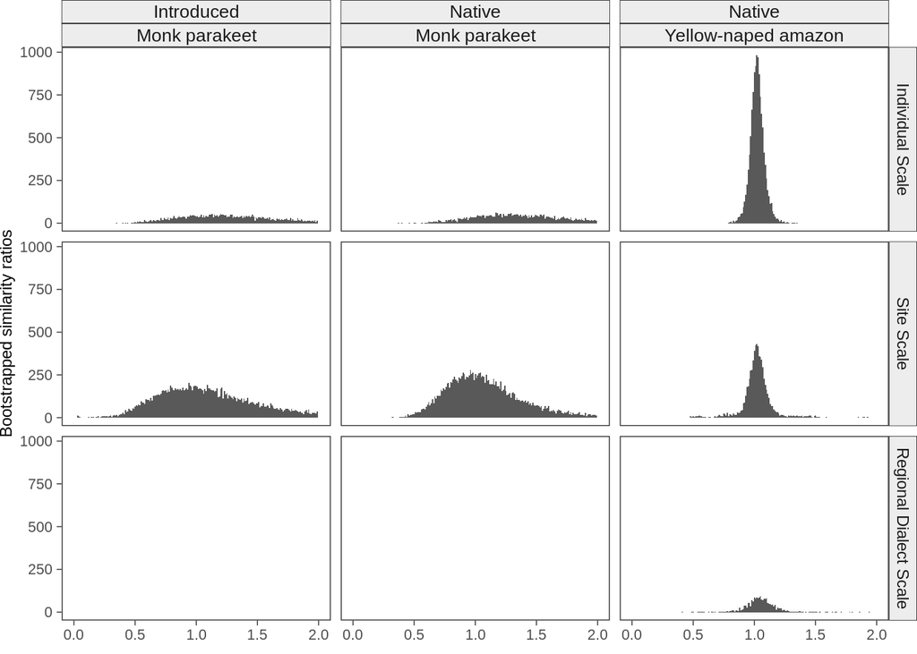

```r
yna_bs_sim_ratio_df %>%
  bind_rows(mnk_bs_sim_ratio_df) %>%
  dplyr::mutate(
    social_scale = factor(social_scale, levels = c("Individual Scale", "Site Scale", "Regional Dialect Scale"))
  ) %>%
  ggplot(aes(x = bootstrapped_sim_ratios)) +
  facet_grid(cols = vars(range, spp), rows = vars(social_scale), scales = "fixed") +
  geom_histogram(binwidth = 0.01) +
  scale_x_continuous(limits = c(0, 2)) +
  xlab("") +
  ylab("Bootstrapped similarity ratios") +
  theme_bw() +
  theme(
    plot.margin = ggplot2::margin(0, 0, -5, 0), # top, right, bottom, left
    panel.grid.major = element_blank(),
    panel.grid.minor = element_blank(),
    strip.text.y = element_text(size = 9, margin = ggplot2::margin(0.25, 0.25, 0.25, 0.25, "lines")),
    strip.text.x = element_text(size = 10, margin = ggplot2::margin(0.15, 0.15, 0.15, 0.15, "lines")),
    strip.background.y = element_rect(linewidth = 0.25, color = "black", fill = "grey93"),
    strip.background.x = element_rect(linewidth = 0.25, color = "black", fill = "grey93"),
    axis.text.x = element_text(size = 8),
    axis.text.y = element_text(size = 8),
    axis.title = element_text(size = 9),
    axis.ticks = element_line(linewidth = 0.25)
  )
```

Make the visual between species. These are kernel density curves (the default is a Gaussian kernel). Also see ?bandwidth: the default bandwidth is chosen using the bw.nrd0() rule-of-thumb in geom_density().

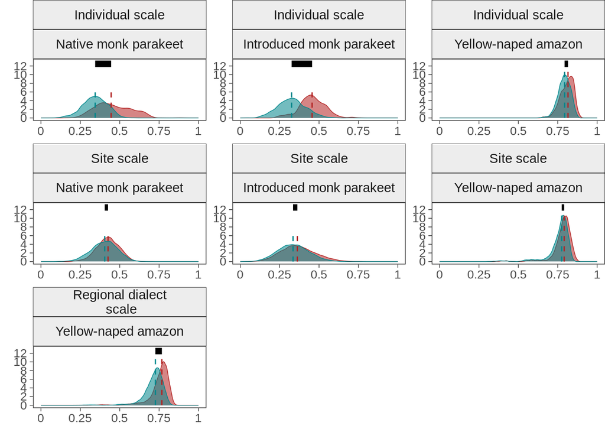

```r
# Combine data between species and plot density curves of SPCC distributions
# Full dataset only for parakeet site scale
gg_df <- yna_spcc_vals_df %>%
  bind_rows(
    mnk_spcc_vals_df %>%
      dplyr::filter(dataset == "Full" | dataset == "")
  ) %>%
  dplyr::mutate(
    spp = gsub("Monk parakeet", "monk parakeet", spp),
    range = ifelse(spp == "Yellow-naped amazon", "", range),
    range_spp = paste(range, spp, sep = " "),
    range_spp = ifelse(spp == "Yellow-naped amazon", "Yellow-naped amazon", range_spp),
    range_spp = factor(range_spp, levels = c("Native monk parakeet", "Introduced monk parakeet", "Yellow-naped amazon")),
    spp = factor(spp, levels = c("monk parakeet", "Yellow-naped amazon")),
    social_scale = gsub("Scale", "scale", social_scale),
    social_scale = gsub("Regional Dialect", "Regional dialect\n", social_scale),
    social_scale = factor(social_scale, levels = c("Individual scale", "Site scale", "Regional dialect\n scale")),
    type = gsub("dif", "Dif", type),
    type = gsub("sam", "Sam", type),
    type = factor(type, levels = c("Same", "Different", "original SPCC"))
  )

# glimpse(gg_df)

# unique(gg_df$range_spp)
# unique(gg_df$type)

# Make a data frame of median values per similarity type across species and social scales
medians_df <- gg_df %>%
  group_by(spp, range_spp, social_scale, type) %>%
  dplyr::summarise(
    median_val = median(similarity_value)
  ) %>%
  ungroup() %>%
  # Add a column that will be used to delineate the maximum height of each mean line per species
  dplyr::mutate(
    y_lim = ifelse(spp == "monk parakeet", 6, 11.5)
  )

# medians_df

# Make a data frame based on the medians to add a bar above each pair of distributions that shows the separation between these
sep_bars_df <- gg_df %>%
  group_by(spp, range_spp, social_scale, type) %>%
  dplyr::summarise(
    median_val = median(similarity_value)
  ) %>%
  ungroup() %>%
  pivot_wider(
    names_from = "type",
    values_from = "median_val"
  ) %>%
  # Add a column that will be used to delineate the maximum height of each mean line per species
  dplyr::mutate(
    y_lim = ifelse(spp == "Monk parakeet", 7, 12.5)
  )

# glimpse(sep_bars_df)

# Fills and colors by type of similarity (different or same group per social scale)
fills <- c(alpha("firebrick", 0.55), alpha("turquoise4", 0.55))
cols <- c("firebrick", "turquoise4")

gg_df %>%
  ggplot() +
  # facet_grid(cols = vars(range_spp), rows = vars(social_scale), scales = "free") +
  facet_wrap(vars(social_scale, range_spp), scales = "free", strip.position = c("top")) +
  geom_density(aes(x = similarity_value, fill = type, color = type), linewidth = 0.25, bw = "nrd0") +
  # Add lines for medians per distribution
  geom_segment(data = medians_df, aes(x = median_val, xend = median_val, y = 0, yend = y_lim, color = type), linetype = "dashed", linewidth = 0.50) +
  # Add a bar above the distributions showing the separation between the two
  geom_segment(data = sep_bars_df, aes(x = Same, xend = Different, y = y_lim, yend = y_lim), color = "black", linetype = "solid", linewidth = 2.50) +
  scale_y_continuous(limits = c(0, 13), breaks = seq(0, 13, 2), labels = seq(0, 13, 2)) +
  scale_x_continuous(limits = c(0, 1), breaks = seq(0, 1, 0.25), labels = seq(0, 1, 0.25)) +
  scale_fill_manual(values = fills) +
  scale_color_manual(values = cols) +
  guides(fill = "none", color = "none") +
  xlab("") +
  ylab("") +
  theme_bw() +
  theme(
    plot.margin = ggplot2::margin(0, 0, -5, 0), # top, right, bottom, left
    panel.grid.major = element_blank(),
    panel.grid.minor = element_blank(),
    strip.text.x = element_text(size = 11, margin = ggplot2::margin(0.1, 0.1, 0.1, 0.1, "lines")),
    strip.background.y = element_rect(linewidth = 0.25, color = "black", fill = "grey93"),
    strip.background.x = element_rect(linewidth = 0.25, color = "black", fill = "grey93"),
    axis.text.x = element_text(size = 10),
    axis.text.y = element_text(size = 10),
    axis.title = element_text(size = 10),
    axis.ticks = element_line(linewidth = 0.25)
  )
```

```r
# ggsave(file.path(gpath, "species_comparison_benchmarking.tiff"), units = "in", width = 7.48, height = 6.5, dpi = 300)
```

Combine bootstrapping results.

```r
yna_sim_rat <- yna_bs_sim_ratio_df %>%
  dplyr::filter(!is.na(bootstrapped_sim_ratios)) %>%
  group_by(spp, range, social_scale) %>%
  # Get the overall mean and SD of the bootstrapped similarity ratios
  dplyr::summarise(
    mean_sim_ratio = mean(bootstrapped_sim_ratios),
    sd_vals = sd(bootstrapped_sim_ratios)
  ) %>%
  ungroup() %>%
  dplyr::mutate(
    dataset = "Full"
  ) %>%
  dplyr::select(spp, dataset, range, social_scale, mean_sim_ratio, sd_vals)

glimpse(yna_sim_rat)
```

```
## Rows: 3
## Columns: 6
## $ spp            <chr> "Yellow-naped amazon", "Yellow-naped amazon", "Yellow-n…
## $ dataset        <chr> "Full", "Full", "Full"
## $ range          <chr> "Native", "Native", "Native"
## $ social_scale   <chr> "Individual Scale", "Regional Dialect Scale", "Site Sca…
## $ mean_sim_ratio <dbl> 1.023346, 1.066268, 1.036371
## $ sd_vals        <dbl> 0.05837792, 0.18467660, 0.17472595
```

```r
mnk_sim_rat <- mnk_bs_sim_ratio_df %>%
  dplyr::filter(!is.na(bootstrapped_sim_ratios)) %>%
# Get the overall mean and SD of the bootstrapped similarity ratios
  group_by(spp, dataset, range, social_scale) %>%
  dplyr::summarise(
    mean_sim_ratio = mean(bootstrapped_sim_ratios),
    sd_vals = sd(bootstrapped_sim_ratios)
  ) %>%
  ungroup() %>%
  dplyr::select(spp, dataset, range, social_scale, mean_sim_ratio, sd_vals)


glimpse(mnk_sim_rat)
```

```
## Rows: 8
## Columns: 6
## $ spp            <chr> "Monk parakeet", "Monk parakeet", "Monk parakeet", "Mon…
## $ dataset        <chr> "", "", "Clustering", "Clustering", "Full", "Full", "Vi…
## $ range          <chr> "Introduced", "Native", "Introduced", "Native", "Introd…
## $ social_scale   <chr> "Individual Scale", "Individual Scale", "Site Scale", "…
## $ mean_sim_ratio <dbl> 1.424668, 1.465559, 1.201107, 1.103094, 1.162513, 1.089…
## $ sd_vals        <dbl> 0.6819196, 0.5110151, 0.6331466, 0.3771197, 0.5924163, …
```

```r
# mnk_sim_rat

# Combine summary statistics of bootstrapping results
comb_vals <- yna_sim_rat %>%
  bind_rows(
    mnk_sim_rat
  ) %>%
  dplyr::mutate(
    mean_sim_ratio = round(mean_sim_ratio, 3),
    sd_vals = round(sd_vals, 3)
  ) %>%
  arrange(desc(range))

comb_vals %>%
  kable()
```

| spp | dataset | range | social_scale | mean_sim_ratio | sd_vals |
| --- | --- | --- | --- | --- | --- |
| Yellow-naped amazon | Full | Native | Individual Scale | 1.023 | 0.058 |
| Yellow-naped amazon | Full | Native | Regional Dialect Scale | 1.066 | 0.185 |
| Yellow-naped amazon | Full | Native | Site Scale | 1.036 | 0.175 |
| Monk parakeet |  | Native | Individual Scale | 1.466 | 0.511 |
| Monk parakeet | Clustering | Native | Site Scale | 1.103 | 0.377 |
| Monk parakeet | Full | Native | Site Scale | 1.089 | 0.361 |
| Monk parakeet | Visual classification | Native | Site Scale | 1.117 | 0.387 |
| Monk parakeet |  | Introduced | Individual Scale | 1.425 | 0.682 |
| Monk parakeet | Clustering | Introduced | Site Scale | 1.201 | 0.633 |
| Monk parakeet | Full | Introduced | Site Scale | 1.163 | 0.592 |
| Monk parakeet | Visual classification | Introduced | Site Scale | 1.215 | 0.663 |

Make a plot of the bootstrapped statistics.

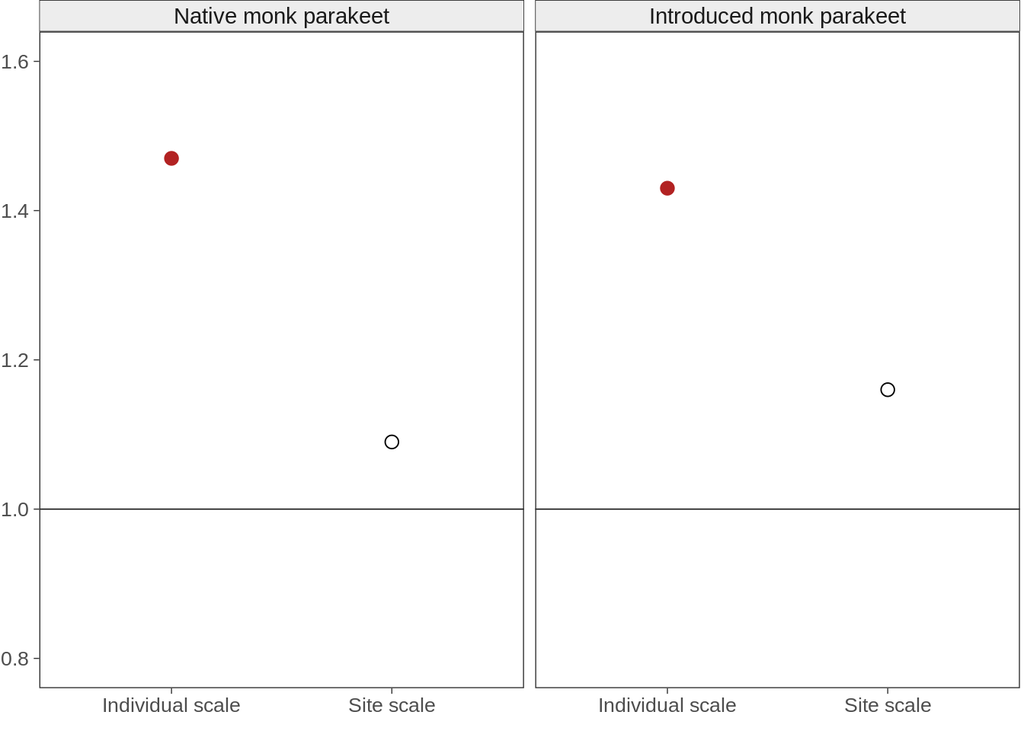

```r
gg_bs_df <- comb_vals %>%
  dplyr::filter(dataset == "Full" | dataset == "") %>%
  dplyr::mutate(
    mean_sim_ratio = round(mean_sim_ratio, 2),
    sd_vals = round(sd_vals, 2)
  ) %>%
  dplyr::mutate(
    spp = gsub("Monk parakeet", "monk parakeet", spp),
    range = ifelse(spp == "Yellow-naped amazon", "", range),
    range_spp = paste(range, spp, sep = " "),
    range_spp = ifelse(spp == "Yellow-naped amazon", "Yellow-naped amazon", range_spp),
    range_spp = factor(range_spp, levels = c("Native monk parakeet", "Introduced monk parakeet", "Yellow-naped amazon")),
    social_scale = gsub(" Scale", " scale", social_scale),
    social_scale = gsub("Dialect", "dialect", social_scale),
    social_scale = factor(social_scale, levels = c("Individual scale", "Site scale", "Regional dialect scale")),
    strength = paste(spp, social_scale, sep = "-"),
    strength = factor(strength, levels = c("monk parakeet-Individual scale", "monk parakeet-Site scale", "Yellow-naped amazon-Individual scale", "Yellow-naped amazon-Site scale", "Yellow-naped amazon-Regional dialect scale"))
  )

# glimpse(gg_bs_df)
# gg_bs_df

# unique(gg_bs_df$range_spp)
# levels(gg_bs_df$social_scale)
# unique(gg_bs_df$social_scale)
# levels(gg_bs_df$strength)

# Set point colors by range-species-social scale to show the scales with the strongest convergence. See the order of the levels of the "strength" column
fills <- c("firebrick", "white")
cols <- c("firebrick", "black")

gg_bs_df %>%
  dplyr::filter(spp == "monk parakeet") %>%
  ggplot() +
  facet_grid(cols = vars(range_spp), scales = "fixed", drop = TRUE) +
  geom_point(aes(x = social_scale, y = mean_sim_ratio, color = strength, fill = strength), shape = 21, size = 2.75) +
  geom_hline(aes(yintercept = 1), color = "black", linetype = "solid", size = 0.25) +
  scale_color_manual(values = cols) +
  scale_fill_manual(values = fills) +
  scale_y_continuous(limits = c(0.8, 1.6), breaks = seq(0.8, 1.6, 0.2), labels = sprintf("%.1f", seq(0.8, 1.6, 0.2))) +
  guides(fill = "none", color = "none") +
  xlab("") +
  ylab("") +
  theme_bw() +
  theme(
    plot.margin = ggplot2::margin(0, 2, -5, -12), # top, right, bottom, left
    panel.grid.major = element_blank(),
    panel.grid.minor = element_blank(),
    # strip.text.y = element_text(size = 8, margin = ggplot2::margin(0.25, 0.25, 0.25, 0.25, "lines")),
    strip.text.x = element_text(size = 11, margin = ggplot2::margin(0.2, 0.2, 0.2, 0.2, "lines")),
    strip.background.y = element_rect(linewidth = 0.25, color = "black", fill = "grey93"),
    strip.background.x = element_rect(linewidth = 0.25, color = "black", fill = "grey93"),
    axis.text.x = element_text(size = 10),
    axis.text.y = element_text(size = 10),
    axis.ticks = element_line(linewidth = 0.25)
  )
```

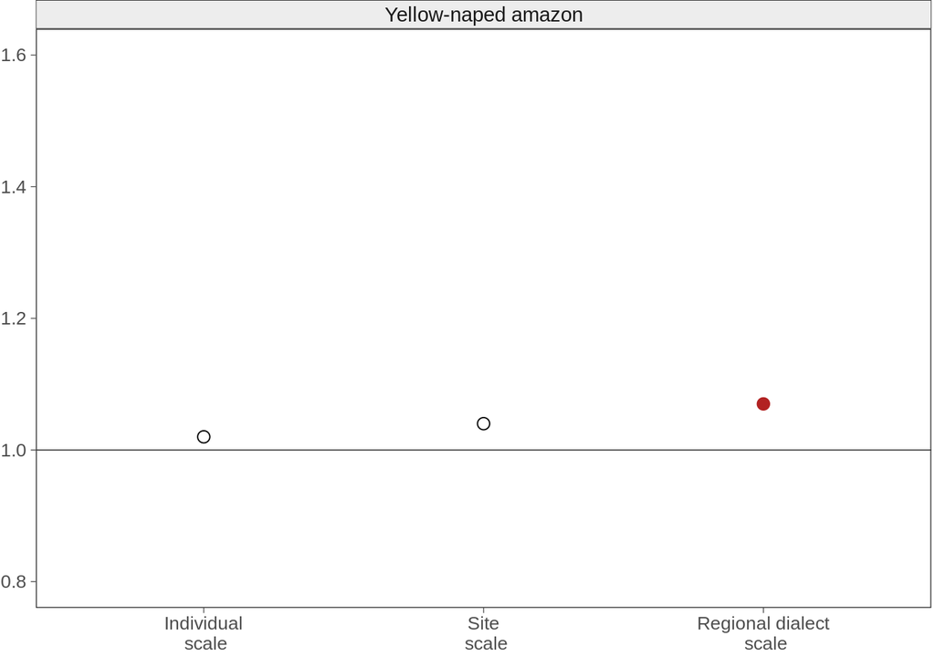

```r
# ggsave(file.path(gpath, "species_comparison_parakeet_benchmarking_bootstrapping.tiff"), units = "in", width = 5, height = 1.65, dpi = 300)


fills <- c("white", "white", "firebrick")
cols <- c("black", "black", "firebrick")

gg_bs_df %>%
  dplyr::filter(spp == "Yellow-naped amazon") %>%
  dplyr::mutate(
    social_scale = gsub(" scale", "\n scale", social_scale),
    social_scale = factor(social_scale, levels = c("Individual\n scale", "Site\n scale", "Regional dialect\n scale"))
  ) %>%
  dplyr::mutate(
    strength = paste(spp, social_scale, sep = "-"),
    strength = factor(strength, levels = c("Yellow-naped amazon-Individual\n scale", "Yellow-naped amazon-Site\n scale", "Yellow-naped amazon-Regional dialect\n scale"))
  ) %>%
  ggplot() +
  facet_grid(cols = vars(range_spp), scales = "fixed", drop = TRUE) +
  geom_point(aes(x = social_scale, y = mean_sim_ratio, color = strength, fill = strength), shape = 21, size = 2.75) +
  geom_hline(aes(yintercept = 1), color = "black", linetype = "solid", size = 0.2) +
  scale_color_manual(values = cols) +
  scale_fill_manual(values = fills) +
  scale_y_continuous(limits = c(0.8, 1.6), breaks = seq(0.8, 1.6, 0.2), labels = sprintf("%.1f", seq(0.8, 1.6, 0.2))) +
  guides(fill = "none", color = "none") +
  xlab("") +
  ylab("") +
  theme_bw() +
  theme(
    plot.margin = ggplot2::margin(0, 2, -5, -12), # top, right, bottom, left
    panel.grid.major = element_blank(),
    panel.grid.minor = element_blank(),
     strip.text.x = element_text(size = 11, margin = ggplot2::margin(0.2, 0.2, 0.2, 0.2, "lines")),
    strip.background.y = element_rect(linewidth = 0.25, color = "black", fill = "grey93"),
    strip.background.x = element_rect(linewidth = 0.25, color = "black", fill = "grey93"),
    axis.text.x = element_text(size = 10),
    axis.text.y = element_text(size = 10),
    axis.ticks = element_line(linewidth = 0.2)
  )
```

```r
# ggsave(file.path(gpath, "species_comparison_amazon_benchmarking_bootstrapping.tiff"), units = "in", width = 2.85, height = 1.77, dpi = 300)
```

# References

```
1. Smith-Vidaurre, G., Araya-Salas, M., and T.F. Wright. 2020. Individual signatures outweigh social group identity in contact calls of a communally nesting parrot. Behavioral Ecology 31(2), 448-458. https://doi.org/10.1093/beheco/arz202

2. Smith-Vidaurre, G., Perez-Marrufo, V., & Wright, T. F. 2021. Individual vocal signatures show reduced complexity following invasion. Animal Behavior, 179, 15–39. https://doi.org/10.1016/j.anbehav.2021.06.020

3. Wright, T. F. (1996). Regional dialects in the contact call of a parrot. Proceedings of the Royal Society of London, B, 263, 867–872. https://doi.org/10.1098/rspb.1996.0128

4. Wright, T. F., Dahlin, C. R., & Salinas-Melgoza, A. (2008). Stability and change in vocal dialects of the yellow-naped amazon. Animal Behavior, 76(3), 1017–1027. https://doi.org/10.1016/j.anbehav.2008.03.025
```